# wrangle_act

### Data Wrangling and Analyzing Project

*Goal: Wrangle WeRateDogs Twitter data to create interesting and trustworthy analyses and visualizations. The Twitter archive is great, but it only contains very basic tweet information. Additional gathering, then assessing and cleaning is required for "Wow!"-worthy analyses and visualizations.*

Key Points Key points to keep in mind when data wrangling for this project:

1. You only want original ratings (no retweets) that have images. Though there are 5000+ tweets in the dataset, not all are dog ratings and some are retweets.
2. Assessing and cleaning the entire dataset completely would require a lot of time, and is not necessary to practice and demonstrate your skills in data wrangling. Therefore, the requirements of this project are only to assess and clean at least 8 quality issues and at least 2 tidiness issues in this dataset.
3. Cleaning includes merging individual pieces of data according to the rules of tidy data.
4. The fact that the rating numerators are greater than the denominators does not need to be cleaned. This unique rating system is a big part of the popularity of WeRateDogs.
5. You do not need to gather the tweets beyond August 1st, 2017. You can, but note that you won't be able to gather the image predictions for these tweets since you don't have access to the algorithm used.

Import necessary python libraries

```python
import pandas as pd
import requests as req
import os
import tweepy
import json
import re
import numpy as np
import tweepy
from tweepy import OAuthHandler
import json
from timeit import default_timer as timer
```

### Gather Data : twitter_archive.csv , image predections and data from twitter api

##### 1. Download the image predictions file and store it

Column Description for Image Predictions File:

1. tweet_id is the last part of the tweet URL after "status/"
2. p1 is the algorithm's #1 prediction for the image in the tweet
3. p1_conf is how confident the algorithm is in its #1 prediction
4. p1_dog is whether or not the #1 prediction is a breed of dog
5. p2 is the algorithm's second most likely prediction
6. p2_conf is how confident the algorithm is in its #2 prediction
7. p2_dog is whether or not the #2 prediction is a breed of dog etc.

```python
#URL to get image predictions
img_pred_url = "https://d17h27t6h515a5.cloudfront.net/topher/2017/August/599fd2ad_image-predictions/image-predictions.tsv"
```

```python
#Get the image predictions tsv file and store it locally
response = req.get(img_pred_url)
with open("image_predictions.tsv",mode = 'wb') as file:
        file.write(response.content)
```

```python
#Check if file has been saved correctly
pred = pd.read_csv("image_predictions.tsv",sep='\t')
pred.head()
```

|  | tweet_id | jpg_url | img_num | p1 | p1_conf | p1_dog | p2 | p2_conf | p2_dog | p3 | p3_conf | p3_dog |
| --- | --- | --- | --- | --- | --- | --- | --- | --- | --- | --- | --- | --- |
| 0 | 666020888022790149 | https://pbs.twimg.com/media/CT4udn0WwAA0aMy.jpg | 1 | Welsh_springer_spaniel | 0.465074 | True | collie | 0.156665 | True | Shetland_sheepdog | 0.061428 | True |
| 1 | 666029285002620928 | https://pbs.twimg.com/media/CT42GRgUYAA5iDo.jpg | 1 | redbone | 0.506826 | True | miniature_pinscher | 0.074192 | True | Rhodesian_ridgeback | 0.072010 | True |
| 2 | 666033412701032449 | https://pbs.twimg.com/media/CT4521TWwAEvMyu.jpg | 1 | German_shepherd | 0.596461 | True | malinois | 0.138584 | True | bloodhound | 0.116197 | True |
| 3 | 666044226329800704 | https://pbs.twimg.com/media/CT5Dr8HUEAA-lEu.jpg | 1 | Rhodesian_ridgeback | 0.408143 | True | redbone | 0.360687 | True | miniature_pinscher | 0.222752 | True |
| 4 | 666049248165822465 | https://pbs.twimg.com/media/CT5IQmsXIAAKY4A.jpg | 1 | miniature_pinscher | 0.560311 | True | Rottweiler | 0.243682 | True | Doberman | 0.154629 | True |

##### 2. Upload twitter enhanced file on the server

```python
# Twitter Archive Enhanced csv file has been manually upload it
# Testing the contents of the twitter file
twitter=pd.read_csv("twitter-archive-enhanced.csv",sep=',')
twitter.head()
```

|  | tweet_id | in_reply_to_status_id | in_reply_to_user_id | timestamp | source | text | retweeted_status_id | retweeted_status_user_id | retweeted_status_timestamp | expanded_urls | rating_numerator | rating_denominator | name | doggo | floofer | pupper | puppo |
| --- | --- | --- | --- | --- | --- | --- | --- | --- | --- | --- | --- | --- | --- | --- | --- | --- | --- |
| 0 | 892420643555336193 | NaN | NaN | 2017-08-01 16:23:56 +0000 | <a href="http://twitter.com/download/iphone" r... | This is Phineas. He's a mystical boy. Only eve... | NaN | NaN | NaN | https://twitter.com/dog_rates/status/892420643... | 13 | 10 | Phineas | None | None | None | None |
| 1 | 892177421306343426 | NaN | NaN | 2017-08-01 00:17:27 +0000 | <a href="http://twitter.com/download/iphone" r... | This is Tilly. She's just checking pup on you.... | NaN | NaN | NaN | https://twitter.com/dog_rates/status/892177421... | 13 | 10 | Tilly | None | None | None | None |
| 2 | 891815181378084864 | NaN | NaN | 2017-07-31 00:18:03 +0000 | <a href="http://twitter.com/download/iphone" r... | This is Archie. He is a rare Norwegian Pouncin... | NaN | NaN | NaN | https://twitter.com/dog_rates/status/891815181... | 12 | 10 | Archie | None | None | None | None |
| 3 | 891689557279858688 | NaN | NaN | 2017-07-30 15:58:51 +0000 | <a href="http://twitter.com/download/iphone" r... | This is Darla. She commenced a snooze mid meal... | NaN | NaN | NaN | https://twitter.com/dog_rates/status/891689557... | 13 | 10 | Darla | None | None | None | None |
| 4 | 891327558926688256 | NaN | NaN | 2017-07-29 16:00:24 +0000 | <a href="http://twitter.com/download/iphone" r... | This is Franklin. He would like you to stop ca... | NaN | NaN | NaN | https://twitter.com/dog_rates/status/891327558... | 12 | 10 | Franklin | None | None | None | None |

##### 3. Collect data from Twitter API results and store it in a dataframe (df_tweet)

#### a.tweet_id : unique identifier of the tweet

#### b.retweet count : Number of times a tweet is retweeted

#### c.favorite count : Number of times a tweet is labelled as favorite

*Used the provided json file as the twitter developer account was not approved for a week.

```python
# Query Twitter API for each tweet in the Twitter archive and save JSON in a text file
# These are hidden to comply with Twitter's API terms and conditions
consumer_key = 'HIDDEN'
consumer_secret = 'HIDDEN'
access_token = 'HIDDEN'
access_secret = 'HIDDEN'

auth = OAuthHandler(consumer_key, consumer_secret)
auth.set_access_token(access_token, access_secret)

api = tweepy.API(auth, wait_on_rate_limit=True)

# NOTE TO STUDENT WITH MOBILE VERIFICATION ISSUES:
# df_1 is a DataFrame with the twitter.csv file.
# NOTE TO REVIEWER: this student had mobile verification issues so the following
# Twitter API code was sent to this student from a Udacity instructor
# Tweet IDs for which to gather additional data via Twitter's API
tweet_ids = twitter.tweet_id.values
len(tweet_ids)

# Query Twitter's API for JSON data for each tweet ID in the Twitter archive
count = 0
fails_dict = {}
start = timer()
# Save each tweet's returned JSON as a new line in a .txt file
with open('tweet_json.txt', 'w') as outfile:
    # This loop will likely take 20-30 minutes to run because of Twitter's rate limit
    for tweet_id in tweet_ids:
        count += 1
        print(str(count) + ": " + str(tweet_id))
        try:
            tweet = api.get_status(tweet_id, tweet_mode='extended')
            print("Success")
            json.dump(tweet._json, outfile)
            outfile.write('\n')
        except tweepy.TweepError as e:
            print("Fail")
            fails_dict[tweet_id] = e
            pass
end = timer()
print(end - start);
print(fails_dict);
```

[output not shown]

[output cut: 712 more lines]

[output not shown]

[output not shown]

[output cut: 97 more lines]

[output not shown]

Observer format of json file to extract variable names

```python
#I will use a manually downloaded file since, the above code failed to retrieve tweets.
data = [json.loads(line) for line in open('tweet-json.json', 'r')]
data[0]
```

```
{'created_at': 'Tue Aug 01 16:23:56 +0000 2017',
 'id': 892420643555336193,
 'id_str': '892420643555336193',
 'full_text': "This is Phineas. He's a mystical boy. Only ever appears in the hole of a donut. 13/10 https://t.co/MgUWQ76dJU",
 'truncated': False,
 'display_text_range': [0, 85],
 'entities': {'hashtags': [],
  'symbols': [],
  'user_mentions': [],
  'urls': [],
  'media': [{'id': 892420639486877696,
    'id_str': '892420639486877696',
    'indices': [86, 109],
    'media_url': 'http://pbs.twimg.com/media/DGKD1-bXoAAIAUK.jpg',
    'media_url_https': 'https://pbs.twimg.com/media/DGKD1-bXoAAIAUK.jpg',
    'url': 'https://t.co/MgUWQ76dJU',
    'display_url': 'pic.twitter.com/MgUWQ76dJU',
    'expanded_url': 'https://twitter.com/dog_rates/status/892420643555336193/photo/1',
    'type': 'photo',
    'sizes': {'large': {'w': 540, 'h': 528, 'resize': 'fit'},
     'thumb': {'w': 150, 'h': 150, 'resize': 'crop'},
     'small': {'w': 540, 'h': 528, 'resize': 'fit'},
     'medium': {'w': 540, 'h': 528, 'resize': 'fit'}}}]},
 'extended_entities': {'media': [{'id': 892420639486877696,
    'id_str': '892420639486877696',
    'indices': [86, 109],
    'media_url': 'http://pbs.twimg.com/media/DGKD1-bXoAAIAUK.jpg',
    'media_url_https': 'https://pbs.twimg.com/media/DGKD1-bXoAAIAUK.jpg',
    'url': 'https://t.co/MgUWQ76dJU',
    'display_url': 'pic.twitter.com/MgUWQ76dJU',
    'expanded_url': 'https://twitter.com/dog_rates/status/892420643555336193/photo/1',
    'type': 'photo',
    'sizes': {'large': {'w': 540, 'h': 528, 'resize': 'fit'},
     'thumb': {'w': 150, 'h': 150, 'resize': 'crop'},
     'small': {'w': 540, 'h': 528, 'resize': 'fit'},
     'medium': {'w': 540, 'h': 528, 'resize': 'fit'}}}]},
 'source': '<a href="http://twitter.com/download/iphone" rel="nofollow">Twitter for iPhone</a>',
 'in_reply_to_status_id': None,
 'in_reply_to_status_id_str': None,
 'in_reply_to_user_id': None,
```

[output cut: 45 more lines]

```
  'follow_request_sent': False,
  'notifications': False,
  'translator_type': 'none'},
 'geo': None,
 'coordinates': None,
 'place': None,
 'contributors': None,
 'is_quote_status': False,
 'retweet_count': 8853,
 'favorite_count': 39467,
 'favorited': False,
 'retweeted': False,
 'possibly_sensitive': False,
 'possibly_sensitive_appealable': False,
 'lang': 'en'}
```

```python
#Create tweets dataframe with tweet ID, retweet count, and favorite count.
col_names=["id","retweet_count",'favorite_count']
df_tweet = pd.DataFrame(data, columns=col_names)
df_tweet.head()
```

|  | id | retweet_count | favorite_count |
| --- | --- | --- | --- |
| 0 | 892420643555336193 | 8853 | 39467 |
| 1 | 892177421306343426 | 6514 | 33819 |
| 2 | 891815181378084864 | 4328 | 25461 |
| 3 | 891689557279858688 | 8964 | 42908 |
| 4 | 891327558926688256 | 9774 | 41048 |

### Assess Data: Visually and Programmatically

#### 1. Assess predictions dataframe for tidyness and quality

```python
pred.head()
```

|  | tweet_id | jpg_url | img_num | p1 | p1_conf | p1_dog | p2 | p2_conf | p2_dog | p3 | p3_conf | p3_dog |
| --- | --- | --- | --- | --- | --- | --- | --- | --- | --- | --- | --- | --- |
| 0 | 666020888022790149 | https://pbs.twimg.com/media/CT4udn0WwAA0aMy.jpg | 1 | Welsh_springer_spaniel | 0.465074 | True | collie | 0.156665 | True | Shetland_sheepdog | 0.061428 | True |
| 1 | 666029285002620928 | https://pbs.twimg.com/media/CT42GRgUYAA5iDo.jpg | 1 | redbone | 0.506826 | True | miniature_pinscher | 0.074192 | True | Rhodesian_ridgeback | 0.072010 | True |
| 2 | 666033412701032449 | https://pbs.twimg.com/media/CT4521TWwAEvMyu.jpg | 1 | German_shepherd | 0.596461 | True | malinois | 0.138584 | True | bloodhound | 0.116197 | True |
| 3 | 666044226329800704 | https://pbs.twimg.com/media/CT5Dr8HUEAA-lEu.jpg | 1 | Rhodesian_ridgeback | 0.408143 | True | redbone | 0.360687 | True | miniature_pinscher | 0.222752 | True |
| 4 | 666049248165822465 | https://pbs.twimg.com/media/CT5IQmsXIAAKY4A.jpg | 1 | miniature_pinscher | 0.560311 | True | Rottweiler | 0.243682 | True | Doberman | 0.154629 | True |

```python
pred.tail()
```

|  | tweet_id | jpg_url | img_num | p1 | p1_conf | p1_dog | p2 | p2_conf | p2_dog | p3 | p3_conf | p3_dog |
| --- | --- | --- | --- | --- | --- | --- | --- | --- | --- | --- | --- | --- |
| 2070 | 891327558926688256 | https://pbs.twimg.com/media/DF6hr6BUMAAzZgT.jpg | 2 | basset | 0.555712 | True | English_springer | 0.225770 | True | German_short-haired_pointer | 0.175219 | True |
| 2071 | 891689557279858688 | https://pbs.twimg.com/media/DF_q7IAWsAEuuN8.jpg | 1 | paper_towel | 0.170278 | False | Labrador_retriever | 0.168086 | True | spatula | 0.040836 | False |
| 2072 | 891815181378084864 | https://pbs.twimg.com/media/DGBdLU1WsAANxJ9.jpg | 1 | Chihuahua | 0.716012 | True | malamute | 0.078253 | True | kelpie | 0.031379 | True |
| 2073 | 892177421306343426 | https://pbs.twimg.com/media/DGGmoV4XsAAUL6n.jpg | 1 | Chihuahua | 0.323581 | True | Pekinese | 0.090647 | True | papillon | 0.068957 | True |
| 2074 | 892420643555336193 | https://pbs.twimg.com/media/DGKD1-bXoAAIAUK.jpg | 1 | orange | 0.097049 | False | bagel | 0.085851 | False | banana | 0.076110 | False |

Visually the data looks good.

```python
pred.info()
```

```
<class 'pandas.core.frame.DataFrame'>
RangeIndex: 2075 entries, 0 to 2074
Data columns (total 12 columns):
tweet_id    2075 non-null int64
jpg_url     2075 non-null object
img_num     2075 non-null int64
p1          2075 non-null object
p1_conf     2075 non-null float64
p1_dog      2075 non-null bool
p2          2075 non-null object
p2_conf     2075 non-null float64
p2_dog      2075 non-null bool
p3          2075 non-null object
p3_conf     2075 non-null float64
p3_dog      2075 non-null bool
dtypes: bool(3), float64(3), int64(2), object(4)
memory usage: 152.1+ KB
```

Image predictions data has 2075 rows. None of the value is missing. Data types also look correctly assigned.

```python
pred.describe()
```

|  | tweet_id | img_num | p1_conf | p2_conf | p3_conf |
| --- | --- | --- | --- | --- | --- |
| count | 2.075000e+03 | 2075.000000 | 2075.000000 | 2.075000e+03 | 2.075000e+03 |
| mean | 7.384514e+17 | 1.203855 | 0.594548 | 1.345886e-01 | 6.032417e-02 |
| std | 6.785203e+16 | 0.561875 | 0.271174 | 1.006657e-01 | 5.090593e-02 |
| min | 6.660209e+17 | 1.000000 | 0.044333 | 1.011300e-08 | 1.740170e-10 |
| 25% | 6.764835e+17 | 1.000000 | 0.364412 | 5.388625e-02 | 1.622240e-02 |
| 50% | 7.119988e+17 | 1.000000 | 0.588230 | 1.181810e-01 | 4.944380e-02 |
| 75% | 7.932034e+17 | 1.000000 | 0.843855 | 1.955655e-01 | 9.180755e-02 |
| max | 8.924206e+17 | 4.000000 | 1.000000 | 4.880140e-01 | 2.734190e-01 |

1. img_num can be between 1 to 4. There is no error here.
2. Confidence levels are within the range 0 to 1
3. Confidence levels of p2 and p3 are very low

```python
pred['tweet_id'].duplicated().sum()
```

```
0
```

There are no duplicate tweet_id entries in the image prediction dataframe.

Visually and programmically the data image_predictions.tsv looks clean. There is no cleaning action required for this dataframe. Now we will check twitter dataframe.

#### 2. Assess twitter dataframe for tidyness and quality

```python
twitter.head()
```

|  | tweet_id | in_reply_to_status_id | in_reply_to_user_id | timestamp | source | text | retweeted_status_id | retweeted_status_user_id | retweeted_status_timestamp | expanded_urls | rating_numerator | rating_denominator | name | doggo | floofer | pupper | puppo |
| --- | --- | --- | --- | --- | --- | --- | --- | --- | --- | --- | --- | --- | --- | --- | --- | --- | --- |
| 0 | 892420643555336193 | NaN | NaN | 2017-08-01 16:23:56 +0000 | <a href="http://twitter.com/download/iphone" r... | This is Phineas. He's a mystical boy. Only eve... | NaN | NaN | NaN | https://twitter.com/dog_rates/status/892420643... | 13 | 10 | Phineas | None | None | None | None |
| 1 | 892177421306343426 | NaN | NaN | 2017-08-01 00:17:27 +0000 | <a href="http://twitter.com/download/iphone" r... | This is Tilly. She's just checking pup on you.... | NaN | NaN | NaN | https://twitter.com/dog_rates/status/892177421... | 13 | 10 | Tilly | None | None | None | None |
| 2 | 891815181378084864 | NaN | NaN | 2017-07-31 00:18:03 +0000 | <a href="http://twitter.com/download/iphone" r... | This is Archie. He is a rare Norwegian Pouncin... | NaN | NaN | NaN | https://twitter.com/dog_rates/status/891815181... | 12 | 10 | Archie | None | None | None | None |
| 3 | 891689557279858688 | NaN | NaN | 2017-07-30 15:58:51 +0000 | <a href="http://twitter.com/download/iphone" r... | This is Darla. She commenced a snooze mid meal... | NaN | NaN | NaN | https://twitter.com/dog_rates/status/891689557... | 13 | 10 | Darla | None | None | None | None |
| 4 | 891327558926688256 | NaN | NaN | 2017-07-29 16:00:24 +0000 | <a href="http://twitter.com/download/iphone" r... | This is Franklin. He would like you to stop ca... | NaN | NaN | NaN | https://twitter.com/dog_rates/status/891327558... | 12 | 10 | Franklin | None | None | None | None |

```python
twitter.info()
```

```
<class 'pandas.core.frame.DataFrame'>
RangeIndex: 2356 entries, 0 to 2355
Data columns (total 17 columns):
tweet_id                      2356 non-null int64
in_reply_to_status_id         78 non-null float64
in_reply_to_user_id           78 non-null float64
timestamp                     2356 non-null object
source                        2356 non-null object
text                          2356 non-null object
retweeted_status_id           181 non-null float64
retweeted_status_user_id      181 non-null float64
retweeted_status_timestamp    181 non-null object
expanded_urls                 2297 non-null object
rating_numerator              2356 non-null int64
rating_denominator            2356 non-null int64
name                          2356 non-null object
doggo                         2356 non-null object
floofer                       2356 non-null object
pupper                        2356 non-null object
puppo                         2356 non-null object
dtypes: float64(4), int64(3), object(10)
memory usage: 313.0+ KB
```

There are 181 retweets.Expanded URLs has some missing values. Total 2356 rows and 17 columns

```python
twitter.describe()
```

|  | tweet_id | in_reply_to_status_id | in_reply_to_user_id | retweeted_status_id | retweeted_status_user_id | rating_numerator | rating_denominator |
| --- | --- | --- | --- | --- | --- | --- | --- |
| count | 2.356000e+03 | 7.800000e+01 | 7.800000e+01 | 1.810000e+02 | 1.810000e+02 | 2356.000000 | 2356.000000 |
| mean | 7.427716e+17 | 7.455079e+17 | 2.014171e+16 | 7.720400e+17 | 1.241698e+16 | 13.126486 | 10.455433 |
| std | 6.856705e+16 | 7.582492e+16 | 1.252797e+17 | 6.236928e+16 | 9.599254e+16 | 45.876648 | 6.745237 |
| min | 6.660209e+17 | 6.658147e+17 | 1.185634e+07 | 6.661041e+17 | 7.832140e+05 | 0.000000 | 0.000000 |
| 25% | 6.783989e+17 | 6.757419e+17 | 3.086374e+08 | 7.186315e+17 | 4.196984e+09 | 10.000000 | 10.000000 |
| 50% | 7.196279e+17 | 7.038708e+17 | 4.196984e+09 | 7.804657e+17 | 4.196984e+09 | 11.000000 | 10.000000 |
| 75% | 7.993373e+17 | 8.257804e+17 | 4.196984e+09 | 8.203146e+17 | 4.196984e+09 | 12.000000 | 10.000000 |
| max | 8.924206e+17 | 8.862664e+17 | 8.405479e+17 | 8.874740e+17 | 7.874618e+17 | 1776.000000 | 170.000000 |

The mininum value for numerator and denominator is 0, which looks quite odd.

```python
twitter.groupby('rating_denominator').tweet_id.count()
```

```
rating_denominator
0         1
2         1
7         1
10     2333
11        3
15        1
16        1
20        2
40        1
50        3
70        1
80        2
90        1
110       1
120       1
130       1
150       1
170       1
Name: tweet_id, dtype: int64
```

Denominator should always be equal to 10.

```python
pd.set_option('display.max_colwidth', -1) #To test entire text set text visibility of all columns to max length.
twitter.query('rating_denominator != 10').text
```

```
313     @jonnysun @Lin_Manuel ok jomny I know you're excited but 960/00 isn't a valid rating, 13/10 is tho
342     @docmisterio account started on 11/15/15
433     The floofs have been released I repeat the floofs have been released. 84/70 https://t.co/NIYC820tmd
516     Meet Sam. She smiles 24/7 &amp; secretly aspires to be a reindeer. \nKeep Sam smiling by clicking and sharing this link:\nhttps://t.co/98tB8y7y7t https://t.co/LouL5vdvxx
784     RT @dog_rates: After so many requests, this is Bretagne. She was the last surviving 9/11 search dog, and our second ever 14/10. RIP https:/…
902     Why does this never happen at my front door... 165/150 https://t.co/HmwrdfEfUE
1068    After so many requests, this is Bretagne. She was the last surviving 9/11 search dog, and our second ever 14/10. RIP https://t.co/XAVDNDaVgQ
1120    Say hello to this unbelievably well behaved squad of doggos. 204/170 would try to pet all at once https://t.co/yGQI3He3xv
1165    Happy 4/20 from the squad! 13/10 for all https://t.co/eV1diwds8a
1202    This is Bluebert. He just saw that both #FinalFur match ups are split 50/50. Amazed af. 11/10 https://t.co/Kky1DPG4iq
1228    Happy Saturday here's 9 puppers on a bench. 99/90 good work everybody https://t.co/mpvaVxKmc1
1254    Here's a brigade of puppers. All look very prepared for whatever happens next. 80/80 https://t.co/0eb7R1Om12
1274    From left to right:\nCletus, Jerome, Alejandro, Burp, &amp; Titson\nNone know where camera is. 45/50 would hug all at once https://t.co/sedre1ivTK
1351    Here is a whole flock of puppers.  60/50 I'll take the lot https://t.co/9dpcw6MdWa
1433    Happy Wednesday here's a bucket of pups. 44/40 would pet all at once https://t.co/HppvrYuamZ
1598    Yes I do realize a rating of 4/20 would've been fitting. However, it would be unjust to give these cooperative pups that low of a rating
1634    Two sneaky puppers were not initially seen, moving the rating to 143/130. Please forgive us. Thank you https://t.co/kRK51Y5ac3
1635    Someone help the girl is being mugged. Several are distracting her while two steal her shoes. Clever puppers 121/110 https://t.co/1zfnTJLt55
1662    This is Darrel. He just robbed a 7/11 and is in a high speed police chase. Was just spotted by the helicopter 10/10 https://t.co/7EsP8LmSp5
1663    I'm aware that I could've said 20/16, but here at WeRateDogs we are very professional. An inconsistent rating scale is simply irresponsible
1779    IT'S PUPPERGEDDON. Total of 144/120 ...I think https://t.co/ZanVtAtvIq
1843    Here we have an entire platoon of puppers. Total score: 88/80 would pet all at once https://t.co/y93p6FLvVw
2335    This is an Albanian 3 1/2 legged  Episcopalian. Loves well-polished hardwood flooring. Penis on the collar. 9/10 https://t.co/d9NcXFKwLv
Name: text, dtype: object
```

For tweets with fractions in it, numerators and denomintors are not correctly extracted (e.g id 313) Others seem to be pure exaggerations (e.g id 1779)

```python
twitter.groupby('rating_numerator').tweet_id.count()
```

```
rating_numerator
0       2
1       9
2       9
3       19
4       17
5       37
6       32
7       55
8       102
9       158
10      461
11      464
12      558
13      351
```

[output cut: 27 more lines]

Users can choose values for numerators greater than 10. Some super high values look very exaggerated. However, ratings less than 5 looks unusual.

```python
twitter.query('rating_numerator < 5')[['text','rating_numerator']]
```

|  | text | rating_numerator |
| --- | --- | --- |
| 315 | When you're so blinded by your systematic plagiarism that you forget what day it is. 0/10 https://t.co/YbEJPkg4Ag | 0 |
| 605 | RT @dog_rates: Not familiar with this breed. No tail (weird). Only 2 legs. Doesn't bark. Surprisingly quick. Shits eggs. 1/10 https://t.co/… | 1 |
| 765 | This is Wesley. He's clearly trespassing. Seems rather h*ckin violent too. Weaponized forehead. 3/10 wouldn't let in https://t.co/pL7wbMRW7M | 3 |
| 883 | This is Fido. He can tell the weather. Not good at fetch tho. Never comes when called. 4/10 would probably still pet https://t.co/4gOv2Q3iKP | 4 |
| 912 | Here's another picture without a dog in it. Idk why you guys keep sending these. 4/10 just because that's a neat rug https://t.co/mOmnL19Wsl | 4 |
| 1004 | Viewer discretion is advised. This is a terrible attack in progress. Not even in water (tragic af). 4/10 bad sherk https://t.co/L3U0j14N5R | 4 |
| 1016 | PUPDATE: can't see any. Even if I could, I couldn't reach them to pet. 0/10 much disappointment https://t.co/c7WXaB2nqX | 0 |
| 1165 | Happy 4/20 from the squad! 13/10 for all https://t.co/eV1diwds8a | 4 |
| 1189 | This is Alexanderson. He's got a weird ass birth mark. Dreadful at fetch. Won't eat kibble. 3/10 wtf @Target https://t.co/FmxOpf2Sgl | 3 |
| 1219 | This is Benedict. He's a feisty pup. Needs a brushing. Portable af. Looks very angry actually. 4/10 might not pet https://t.co/3oeFfHjv0Z | 4 |
| 1249 | What hooligan sent in pictures w/out a dog in them? Churlish af. 3/10 just bc that's a neat fluffy bean bag chair https://t.co/wcwoGOkZvz | 3 |
| 1303 | This is Keurig. He's a rare dog. Laughs like an idiot tho. Head is basically a weapon. Poorly maintained goatee 4/10 https://t.co/xOrUyj7K30 | 4 |
| 1314 | This is Elliot. He's blocking the roadway. Downright rude as hell. Doesn't care that you're already late. 3/10 https://t.co/FMUxir5pYu | 3 |
| 1406 | This is Charl. He's a bully. Chucks that dumbbell around like its nothing. Sharp neck. Exceptionally unfluffy. 3/10 https://t.co/VfLoDZecJ7 | 3 |
| 1446 | After reading the comments I may have overestimated this pup. Downgraded to a 1/10. Please forgive me | 1 |
| 1459 | This may be the greatest video I've ever been sent. 4/10 for Charles the puppy, 13/10 overall. (Vid by @stevenxx_) https://t.co/uaJmNgXR2P | 4 |
| 1478 | Meet Phil. He's big af. Currently destroying this nice family home. Completely uncalled for. 3/10 not a good pupper https://t.co/fShNNhBWYx | 3 |
| 1598 | Yes I do realize a rating of 4/20 would've been fitting. However, it would be unjust to give these cooperative pups that low of a rating | 4 |
| 1601 | This is Hammond. He's a peculiar pup. Loves long walks. Bark barely audible. Too many legs. 3/10 must be rare https://t.co/NOIiRWr5Jf | 3 |
| 1629 | This is Bobby. He doesn't give a damn about personal space. Convinced he called shotgun first. 4/10 not the best dog https://t.co/b8XW69gSaU | 4 |
| 1692 | This is Chuck. He's a neat dog. Very flexible. Trapped in a glass case of emotion. Devastatingly unfluffy 3/10 https://t.co/YqbU9xHV3p | 3 |
| 1701 | This is Alice. She's an idiot. 4/10 https://t.co/VQXdwJfkyS | 4 |
| 1761 | Exotic pup here. Tail long af. Throat looks swollen. Might breathe fire. Exceptionally unfluffy 2/10 would still pet https://t.co/a8SqCaSo2r | 2 |
| 1764 | This is Crystal. She's a shitty fireman. No sense of urgency. People could be dying Crystal. 2/10 just irresponsible https://t.co/rtMtjSl9pz | 2 |
| 1836 | Extremely rare pup here. Very religious. Always praying. Too many legs. Not overwhelmingly fluffy. Won't bark. 3/10 https://t.co/REyE5YKVBb | 3 |
| 1869 | What kind of person sends in a picture without a dog in it? 1/10 just because that's a nice table https://t.co/RDXCfk8hK0 | 1 |
| 1898 | Meet Patrick. He's an exotic pup. Jumps great distances for a dog. Always gets injured when I toss him a ball. 3/10 https://t.co/Unz1uNrOzo | 3 |
| 1920 | This is Henry. He's a shit dog. Short pointy ears. Leaves trail of pee. Not fluffy. Doesn't come when called. 2/10 https://t.co/Pu9RhfHDEQ | 2 |
| 1928 | Herd of wild dogs here. Not sure what they're trying to do. No real goals in life. 3/10 find your purpose puppers https://t.co/t5ih0VrK02 | 3 |
| 1938 | Guys I'm getting real tired of this. We only rate dogs. Please don't send in other things like this Bulbasaur. 3/10 https://t.co/t5rQHl6W8M | 3 |
| 1940 | The millennials have spoken and we've decided to immediately demote to a 1/10. Thank you | 1 |
| 1941 | This is a heavily opinionated dog. Loves walls. Nobody knows how the hair works. Always ready for a kiss. 4/10 https://t.co/dFiaKZ9cDl | 4 |
| 1947 | Large blue dog here. Cool shades. Flipping us off w both hands. Obviously a preteen. 3/10 for rude blue preteen pup https://t.co/mcPd5AFfhA | 3 |
| 2038 | After 22 minutes of careful deliberation this dog is being demoted to a 1/10. The longer you look at him the more terrifying he becomes | 1 |
| 2070 | Two miniature golden retrievers here. Webbed paws. Don't walk very efficiently. Can't catch a tennis ball. 4/10s https://t.co/WzVLdSHJU7 | 4 |
| 2076 | Pink dogs here. Unreasonably long necks. Left guy has only 1 leg. Quite nimble. Don't bark tho 4/10s would still pet https://t.co/QY5uvMmmQk | 4 |
| 2079 | Scary dog here. Too many legs. Extra tail. Not soft, let alone fluffy. Won't bark. Moves sideways. Has weapon. 2/10 https://t.co/XOPXCSXiUT | 2 |
| 2091 | Flamboyant pup here. Probably poisonous. Won't eat kibble. Doesn't bark. Slow af. Petting doesn't look fun. 1/10 https://t.co/jxukeh2BeO | 1 |
| 2136 | This is Tommy. He's a cool dog. Hard not to step on. Won't let go of seashell. Not fast by any means. 3/10 https://t.co/0gY6XTOpn3 | 3 |
| 2183 | This is Bernie. He's taking his Halloween costume very seriously. Wants to be baked. 3/10 not a good idea Bernie smh https://t.co/1zBp1moFlX | 3 |
| 2186 | Unique dog here. Oddly shaped tail. Long pink front legs. I don't think dogs breath underwater sos. 4/10 bad owner https://t.co/0EJXxE9UxW | 4 |
| 2202 | Fascinating dog here. Loves beach. Oddly long nose for dog. Massive ass paws. Hard to cuddle w. 3/10 would still pet https://t.co/IiSdmhkC5N | 3 |
| 2222 | Here is a mother dog caring for her pups. Snazzy red mohawk. Doesn't wag tail. Pups look confused. Overall 4/10 https://t.co/YOHe6lf09m | 4 |
| 2237 | This lil pup is Oliver. Hops around. Has wings but doesn't fly (lame). Annoying chirp. Won't catch tennis balls 2/10 https://t.co/DnhUw0aBM2 | 2 |
| 2239 | This dog resembles a baked potato. Bed looks uncomfortable. No tail. Comes with butter tho. 3/10 petting still fun https://t.co/x89NSCEZCq | 3 |
| 2246 | This is Tedrick. He lives on the edge. Needs someone to hit the gas tho. Other than that he's a baller. 10&amp;2/10 https://t.co/LvP1TTYSCN | 2 |
| 2261 | Never seen dog like this. Breathes heavy. Tilts head in a pattern. No bark. Shitty at fetch. Not even cordless. 1/10 https://t.co/i9iSGNn3fx | 1 |
| 2288 | These are strange dogs. All have toupees. Long neck for dogs. In a shed of sorts? Work in groups? 4/10 still petable https://t.co/PZxSarAfSN | 4 |
| 2305 | My goodness. Very rare dog here. Large. Tail dangerous. Kinda fat. Only eats leaves. Doesn't come when called 3/10 https://t.co/xYGdBrMS9h | 3 |
| 2310 | Unfamiliar with this breed. Ears pointy af. Won't let go of seashell. Won't eat kibble. Not very fast. Bad dog 2/10 https://t.co/EIn5kElY1S | 2 |
| 2316 | Cool dog. Enjoys couch. Low monotone bark. Very nice kicks. Pisses milk (must be rare). Can't go down stairs. 4/10 https://t.co/vXMKrJC81s | 4 |
| 2326 | This is quite the dog. Gets really excited when not in water. Not very soft tho. Bad at fetch. Can't do tricks. 2/10 https://t.co/aMCTNWO94t | 2 |
| 2334 | This is a funny dog. Weird toes. Won't come down. Loves branch. Refuses to eat his food. Hard to cuddle with. 3/10 https://t.co/IIXis0zta0 | 3 |
| 2335 | This is an Albanian 3 1/2 legged Episcopalian. Loves well-polished hardwood flooring. Penis on the collar. 9/10 https://t.co/d9NcXFKwLv | 1 |
| 2338 | Not familiar with this breed. No tail (weird). Only 2 legs. Doesn't bark. Surprisingly quick. Shits eggs. 1/10 https://t.co/Asgdc6kuLX | 1 |
| 2349 | This is an odd dog. Hard on the outside but loving on the inside. Petting still fun. Doesn't play catch well. 2/10 https://t.co/v5A4vzSDdc | 2 |

Some users are providing low ratings to their dogs. However, rating 0, are just some disgrunted users.

```python
twitter.tail()
```

|  | tweet_id | in_reply_to_status_id | in_reply_to_user_id | timestamp | source | text | retweeted_status_id | retweeted_status_user_id | retweeted_status_timestamp | expanded_urls | rating_numerator | rating_denominator | name | doggo | floofer | pupper | puppo |
| --- | --- | --- | --- | --- | --- | --- | --- | --- | --- | --- | --- | --- | --- | --- | --- | --- | --- |
| 2351 | 666049248165822465 | NaN | NaN | 2015-11-16 00:24:50 +0000 | <a href="http://twitter.com/download/iphone" rel="nofollow">Twitter for iPhone</a> | Here we have a 1949 1st generation vulpix. Enjoys sweat tea and Fox News. Cannot be phased. 5/10 https://t.co/4B7cOc1EDq | NaN | NaN | NaN | https://twitter.com/dog_rates/status/666049248165822465/photo/1 | 5 | 10 | None | None | None | None | None |
| 2352 | 666044226329800704 | NaN | NaN | 2015-11-16 00:04:52 +0000 | <a href="http://twitter.com/download/iphone" rel="nofollow">Twitter for iPhone</a> | This is a purebred Piers Morgan. Loves to Netflix and chill. Always looks like he forgot to unplug the iron. 6/10 https://t.co/DWnyCjf2mx | NaN | NaN | NaN | https://twitter.com/dog_rates/status/666044226329800704/photo/1 | 6 | 10 | a | None | None | None | None |
| 2353 | 666033412701032449 | NaN | NaN | 2015-11-15 23:21:54 +0000 | <a href="http://twitter.com/download/iphone" rel="nofollow">Twitter for iPhone</a> | Here is a very happy pup. Big fan of well-maintained decks. Just look at that tongue. 9/10 would cuddle af https://t.co/y671yMhoiR | NaN | NaN | NaN | https://twitter.com/dog_rates/status/666033412701032449/photo/1 | 9 | 10 | a | None | None | None | None |
| 2354 | 666029285002620928 | NaN | NaN | 2015-11-15 23:05:30 +0000 | <a href="http://twitter.com/download/iphone" rel="nofollow">Twitter for iPhone</a> | This is a western brown Mitsubishi terrier. Upset about leaf. Actually 2 dogs here. 7/10 would walk the shit out of https://t.co/r7mOb2m0UI | NaN | NaN | NaN | https://twitter.com/dog_rates/status/666029285002620928/photo/1 | 7 | 10 | a | None | None | None | None |
| 2355 | 666020888022790149 | NaN | NaN | 2015-11-15 22:32:08 +0000 | <a href="http://twitter.com/download/iphone" rel="nofollow">Twitter for iPhone</a> | Here we have a Japanese Irish Setter. Lost eye in Vietnam (?). Big fan of relaxing on stair. 8/10 would pet https://t.co/BLDqew2Ijj | NaN | NaN | NaN | https://twitter.com/dog_rates/status/666020888022790149/photo/1 | 8 | 10 | None | None | None | None | None |

```python
# Check to see if there are duplicate tweeter Ids
twitter.tweet_id.duplicated().sum()
```

```
0
```

Check the full expanded url format for additional information

```python
twitter.expanded_urls.get(0)
```

```
'https://twitter.com/dog_rates/status/892420643555336193/photo/1'
```

Looks like expanded_urls provide no additional information than tweet_id and image_id

Check the source url format for additional information

```python
twitter.source.get(0)
```

```
'<a href="http://twitter.com/download/iphone" rel="nofollow">Twitter for iPhone</a>'
```

Sources are not extracted correctly and addtional html tags are seen.

Check the text column format to find additional observations

```python
twitter.text.get(400)
```

```
'This is Scooter. His lack of opposable thumbs is rendering his resistance to tickling embarrassingly moot. 12/10 would keep tickling https://t.co/F0VWg2GztI'
```

text column contains additional url information along with description

```python
twitter['name'].value_counts()
```

```
None          745
a             55
Charlie       12
Cooper        11
Oliver        11
Lucy          11
Tucker        10
Penny         10
Lola          10
Bo            9
Winston       9
the           8
Sadie         8
an            7
Bailey        7
Buddy         7
Toby          7
Daisy         7
Jack          6
Leo           6
Stanley       6
Dave          6
Koda          6
Milo          6
Bella         6
Scout         6
Oscar         6
Jax           6
Rusty         6
Louis         5
             ..
Grey          1
Rorie         1
Jeb           1
Tebow         1
Dietrich      1
Moofasa       1
Marq          1
Tove          1
Napolean      1
Crumpet       1
Iroh          1
Tycho         1
Sage          1
Tyrus         1
Al            1
Maisey        1
Gerbald       1
Autumn        1
Lacy          1
Skittles      1
Major         1
Divine        1
Snoopy        1
incredibly    1
Dex           1
Kevon         1
Izzy          1
Halo          1
Saydee        1
Amélie        1
Name: name, Length: 957, dtype: int64
```

Closer look on faulty names

```python
twitter.query('name =="very"').text.get(773)
```

```
'RT @dog_rates: We only rate dogs. Pls stop sending in non-canines like this Mongolian grass snake. This is very frustrating. 11/10 https://…'
```

Tweets where 'very' is extracted as name seems to be not belonging to dog photos.

```python
twitter.query('name =="old"').text
```

```
1206    This is old now but it's absolutely heckin fantastic and I can't not share it with you all. 13/10  https://t.co/wJX74TSgzP
Name: text, dtype: object
```

```python
twitter.query('name =="space"').text
```

```
2030    This is space pup. He's very confused. Tries to moonwalk at one point. Super spiffy uniform. 13/10 I love space pup https://t.co/SfPQ2KeLdq
Name: text, dtype: object
```

```python
twitter.query('name =="the"').text
```

```
1527    Stop sending in lobsters. This is the final warning. We only rate dogs. Thank you... 9/10 https://t.co/B9ZXXKJYNx
1603    This is the newly formed pupper a capella group. They're just starting out but I see tons of potential. 8/10 for all https://t.co/wbAcvFoNtn
1797    This is the happiest pupper I've ever seen. 10/10 would trade lives with https://t.co/ep8ATEJwRb
1815    This is the saddest/sweetest/best picture I've been sent. 12/10 😢🐶 https://t.co/vQ2Lw1BLBF
2037    This is the best thing I've ever seen so spread it like wildfire &amp; maybe we'll find the genius who created it. 13/10 https://t.co/q6RsuOVYwU
2212    Never forget this vine. You will not stop watching for at least 15 minutes. This is the second coveted.. 13/10 https://t.co/roqIxCvEB3
2345    This is the happiest dog you will ever see. Very committed owner. Nice couch. 10/10 https://t.co/RhUEAloehK
2346    Here is the Rand Paul of retrievers folks! He's probably good at poker. Can drink beer (lol rad). 8/10 good dog https://t.co/pYAJkAe76p
Name: text, dtype: object
```

There are also tweets with no dog name

Check for inconsistencies in dog stages

```python
twitter.groupby(['doggo','floofer', 'pupper', 'puppo']).tweet_id.count()
```

```
doggo  floofer  pupper  puppo
None   None     None    None     1976
                        puppo    29
                pupper  None     245
       floofer  None    None     9
doggo  None     None    None     83
                        puppo    1
                pupper  None     12
       floofer  None    None     1
Name: tweet_id, dtype: int64
```

Some dogs are having two dog stages. Ideally, they should be just one. The above table shows such cases.

```python
twitter.query('doggo == "doggo"').query('puppo == "puppo"').text
```

```
191    Here's a puppo participating in the #ScienceMarch. Cleverly disguising her own doggo agenda. 13/10 would keep the planet habitable for https://t.co/cMhq16isel
Name: text, dtype: object
```

Seems like the user is using doggo and puppo interchangly.

```python
twitter.query('doggo == "doggo"').query('pupper == "pupper"')[['text']]
```

|  | text |
| --- | --- |
| 460 | This is Dido. She's playing the lead role in "Pupper Stops to Catch Snow Before Resuming Shadow Box with Dried Apple." 13/10 (IG: didodoggo) https://t.co/m7isZrOBX7 |
| 531 | Here we have Burke (pupper) and Dexter (doggo). Pupper wants to be exactly like doggo. Both 12/10 would pet at same time https://t.co/ANBpEYHaho |
| 565 | Like doggo, like pupper version 2. Both 11/10 https://t.co/9IxWAXFqze |
| 575 | This is Bones. He's being haunted by another doggo of roughly the same size. 12/10 deep breaths pupper everything's fine https://t.co/55Dqe0SJNj |
| 705 | This is Pinot. He's a sophisticated doggo. You can tell by the hat. Also pointier than your average pupper. Still 10/10 would pet cautiously https://t.co/f2wmLZTPHd |
| 733 | Pupper butt 1, Doggo 0. Both 12/10 https://t.co/WQvcPEpH2u |
| 778 | RT @dog_rates: Like father (doggo), like son (pupper). Both 12/10 https://t.co/pG2inLaOda |
| 822 | RT @dog_rates: This is just downright precious af. 12/10 for both pupper and doggo https://t.co/o5J479bZUC |
| 889 | Meet Maggie &amp; Lila. Maggie is the doggo, Lila is the pupper. They are sisters. Both 12/10 would pet at the same time https://t.co/MYwR4DQKll |
| 956 | Please stop sending it pictures that don't even have a doggo or pupper in them. Churlish af. 5/10 neat couch tho https://t.co/u2c9c7qSg8 |
| 1063 | This is just downright precious af. 12/10 for both pupper and doggo https://t.co/o5J479bZUC |
| 1113 | Like father (doggo), like son (pupper). Both 12/10 https://t.co/pG2inLaOda |

It seems like some of these tweets have both duggo and pupper photos together

```python
twitter.query('doggo == "doggo"').query('floofer == "floofer"')[['text']]
```

|  | text |
| --- | --- |
| 200 | At first I thought this was a shy doggo, but it's actually a Rare Canadian Floofer Owl. Amateurs would confuse the two. 11/10 only send dogs https://t.co/TXdT3tmuYk |

This tweet seems to be of a Floofer and not a doggo.

#### 3. Assess tweet_df for tidyness and quality

```python
df_tweet.head()
```

|  | id | retweet_count | favorite_count |
| --- | --- | --- | --- |
| 0 | 892420643555336193 | 8853 | 39467 |
| 1 | 892177421306343426 | 6514 | 33819 |
| 2 | 891815181378084864 | 4328 | 25461 |
| 3 | 891689557279858688 | 8964 | 42908 |
| 4 | 891327558926688256 | 9774 | 41048 |

```python
df_tweet.info()
```

```
<class 'pandas.core.frame.DataFrame'>
RangeIndex: 2354 entries, 0 to 2353
Data columns (total 3 columns):
id                2354 non-null int64
retweet_count     2354 non-null int64
favorite_count    2354 non-null int64
dtypes: int64(3)
memory usage: 55.2 KB
```

```python
df_tweet.id.value_counts().sum()
```

```
2354
```

No duplicates or null values.

##### Quality:

1. Missing values for 6 columns a. in_reply_to_status_id b. in_reply_to_user_id c. expanded_urls etc d. retweeted_status_id e. retweeted_status_user_id f. retweeted_status_timestamp
2. source column has HTML markup tags along with url. we need the value for this column. e.g Twitter for iPhone
3. timestamp column can be reformatted to YYYY-MM-dd hh:mm:ss format and we do not need addtional milli-seconds after seconds
4. name values for dogs contain incorrect in many rows. This is extracted from the text field. But due to unstructured texts or missing names in some instances, the correct names are not extracted for all dogs. E.g acutally, unacceptable,etc. Most of these terms can be has first letter in lower-case
5. names with 'very' are wrong images which are not related to dogs and should be removed.
6. It is observered that when phrase 'We only rate dogs' appears in text, the tweet entries are invalid. Such also in the case of tweet of index id 1527
7. text coulmn with no image url should be filtered out. As they could be retweets
8. rating_denominator cannot be more than 10. For ids a to f, the numerators where not correctly extracted.  
   a. For id 313 --> Correct values to numerator 13, denominator 10  
   b. For id 784 --> Correct values to numerator 14, denominator 10  
   c. For id 1068 --> Correct values to numerator 14, denominator 10  
   d. For id 1202 --> Correct values to numerator 11, denominator 10  
   e. For id 1662 --> Correct values to numerator 10, denominator 10  
   f. For id 2335 --> Correct values to numerator 9, denominator 10  
   g. Remove other ids where denominator is not equal to 10
9. rating_numerator check : 2 ids where numerator = 0
10. stage column  
    a. stage for id 191 should be set to puppo  
    b. stage for id 200 should be set to floofer  
    c. There are stages with multiple values, concatenate them
11. Expanded_urls column contains redundant information as tweet_id.
12. Remove rows where retweeted_status_id is present as it indicates retweets and not actual tweets

##### Tidyness:

1. Merge columns doggo, floofer, pupper, puppo values into one new column 'stage'
2. text coulmn has image url of the tweet which should be a seperate column other than text.
3. join table df_tweet with df_twitter with columns retweet_count and favorite_count

## Clean Data

Make a copy of the original data (twitter) . df_twitter will be where we put clean data.

```python
df_twitter = twitter.copy()
```

#### Define

Remove retweets

#### Code

```python
#Remove rows where retweet status id is present
df_twitter=df_twitter[df_twitter['retweeted_status_id'].isnull()]
```

#### Test

```python
assert df_twitter['retweeted_status_id'].value_counts().sum() == 0
```

Remove unwanted 6 columns with missing and inaccurate data:  
a. in_reply_to_status_id  
b. in_reply_to_user_id  
c. expanded_urls  
d. retweeted_status_id  
e. retweeted_status_user_id  
f. retweeted_status_timestamp

#### Code

```python
df_twitter.drop(columns=['in_reply_to_status_id','in_reply_to_user_id','expanded_urls','retweeted_status_id','retweeted_status_user_id','retweeted_status_timestamp'],inplace=True)
```

#### Test

```python
df_twitter.info()
```

```
<class 'pandas.core.frame.DataFrame'>
Int64Index: 2175 entries, 0 to 2355
Data columns (total 11 columns):
tweet_id              2175 non-null int64
timestamp             2175 non-null object
source                2175 non-null object
text                  2175 non-null object
rating_numerator      2175 non-null int64
rating_denominator    2175 non-null int64
name                  2175 non-null object
doggo                 2175 non-null object
floofer               2175 non-null object
pupper                2175 non-null object
puppo                 2175 non-null object
dtypes: int64(3), object(8)
memory usage: 203.9+ KB
```

#### Code

```python
#stage for id 191 should be set to puppo
df_twitter.loc[191,'stage'] = 'puppo'

#stage for id 200 should be set to floofer
df_twitter.loc[200,'stage'] = 'floofer'
```

```python
#check stages with multiple values
df_twitter.groupby(["doggo", "floofer", "pupper", "puppo"]).size().reset_index().rename(columns={0: "count"})
```

|  | doggo | floofer | pupper | puppo | count |
| --- | --- | --- | --- | --- | --- |
| 0 | None | None | None | None | 1831 |
| 1 | None | None | None | puppo | 24 |
| 2 | None | None | pupper | None | 224 |
| 3 | None | floofer | None | None | 9 |
| 4 | doggo | None | None | None | 75 |
| 5 | doggo | None | None | puppo | 1 |
| 6 | doggo | None | pupper | None | 10 |
| 7 | doggo | floofer | None | None | 1 |

```python
#Funtion to replace None and NaN with empty string
def replaceWithEmptyString(column):
    column.replace('None', '', inplace=True)
    column.replace(np.NaN, '', inplace=True)
```

```python
#replace the dog stage columns with empty string where NaN or None exists
replaceWithEmptyString(df_twitter.doggo)
replaceWithEmptyString(df_twitter.puppo)
replaceWithEmptyString(df_twitter.pupper)
replaceWithEmptyString(df_twitter.floofer)

#Concatentate the dog stages into the stage column
df_twitter['stage'] = df_twitter.doggo + df_twitter.floofer + df_twitter.pupper + df_twitter.puppo
df_twitter.loc[df_twitter.stage == 'doggopupper', 'stage'] = 'doggo, pupper'
df_twitter.loc[df_twitter.stage == 'doggopuppo', 'stage'] = 'doggo, puppo'
df_twitter.loc[df_twitter.stage == 'doggofloofer', 'stage'] = 'doggo, floofer'
```

```python
#drop colmns
df_twitter.drop(columns=['doggo','puppo','floofer','pupper'],inplace=True)
```

#### Test

```python
df_twitter.groupby(["stage"]).size().reset_index().rename(columns={0: "count"})
```

|  | stage | count |
| --- | --- | --- |
| 0 |  | 1831 |
| 1 | doggo | 75 |
| 2 | doggo, floofer | 1 |
| 3 | doggo, pupper | 10 |
| 4 | doggo, puppo | 1 |
| 5 | floofer | 9 |
| 6 | pupper | 224 |
| 7 | puppo | 24 |

```python
df_twitter.info()
```

```
<class 'pandas.core.frame.DataFrame'>
Int64Index: 2175 entries, 0 to 2355
Data columns (total 8 columns):
tweet_id              2175 non-null int64
timestamp             2175 non-null object
source                2175 non-null object
text                  2175 non-null object
rating_numerator      2175 non-null int64
rating_denominator    2175 non-null int64
name                  2175 non-null object
stage                 2175 non-null object
dtypes: int64(3), object(5)
memory usage: 232.9+ KB
```

#### Define

Predict dog breed based on pred dataframe (p1_conf > 95% and p1 is True)  
Add the breed column to the df_twitter on tweet_id

#### Code

```python
pred_new = pred.copy()
```

```python
pred_new['breed'] = np.where((pred_new['p1_conf'] > 0.95) & (pred_new['p1_dog'] == True),
                             pred_new['p1'],'NA')
#drop unwanted columns
pred_new.drop(columns={'img_num','p1','p1_conf','p2','p2_conf','p3','p3_conf','p1_dog','p2_dog','p3_dog'},inplace = True)
pred_new.head()
```

|  | tweet_id | jpg_url | breed |
| --- | --- | --- | --- |
| 0 | 666020888022790149 | https://pbs.twimg.com/media/CT4udn0WwAA0aMy.jpg | NA |
| 1 | 666029285002620928 | https://pbs.twimg.com/media/CT42GRgUYAA5iDo.jpg | NA |
| 2 | 666033412701032449 | https://pbs.twimg.com/media/CT4521TWwAEvMyu.jpg | NA |
| 3 | 666044226329800704 | https://pbs.twimg.com/media/CT5Dr8HUEAA-lEu.jpg | NA |
| 4 | 666049248165822465 | https://pbs.twimg.com/media/CT5IQmsXIAAKY4A.jpg | NA |

```python
#join predictions column
df_twitter = df_twitter.merge(pred_new, how ='left',on='tweet_id')
df_twitter.head()
```

|  | tweet_id | timestamp | source | text | rating_numerator | rating_denominator | name | stage | jpg_url | breed |
| --- | --- | --- | --- | --- | --- | --- | --- | --- | --- | --- |
| 0 | 892420643555336193 | 2017-08-01 16:23:56 +0000 | <a href="http://twitter.com/download/iphone" r... | This is Phineas. He's a mystical boy. Only eve... | 13 | 10 | Phineas |  | https://pbs.twimg.com/media/DGKD1-bXoAAIAUK.jpg | NA |
| 1 | 892177421306343426 | 2017-08-01 00:17:27 +0000 | <a href="http://twitter.com/download/iphone" r... | This is Tilly. She's just checking pup on you.... | 13 | 10 | Tilly |  | https://pbs.twimg.com/media/DGGmoV4XsAAUL6n.jpg | NA |
| 2 | 891815181378084864 | 2017-07-31 00:18:03 +0000 | <a href="http://twitter.com/download/iphone" r... | This is Archie. He is a rare Norwegian Pouncin... | 12 | 10 | Archie |  | https://pbs.twimg.com/media/DGBdLU1WsAANxJ9.jpg | NA |
| 3 | 891689557279858688 | 2017-07-30 15:58:51 +0000 | <a href="http://twitter.com/download/iphone" r... | This is Darla. She commenced a snooze mid meal... | 13 | 10 | Darla |  | https://pbs.twimg.com/media/DF_q7IAWsAEuuN8.jpg | NA |
| 4 | 891327558926688256 | 2017-07-29 16:00:24 +0000 | <a href="http://twitter.com/download/iphone" r... | This is Franklin. He would like you to stop ca... | 12 | 10 | Franklin |  | https://pbs.twimg.com/media/DF6hr6BUMAAzZgT.jpg | NA |

```python
df_twitter['breed'].fillna('NA');
```

#### Test

```python
df_twitter['breed'].value_counts()
```

```
NA                             1808
pug                              20
Pembroke                         19
Samoyed                          19
golden_retriever                 16
Pomeranian                       13
Labrador_retriever                9
Chihuahua                         9
French_bulldog                    8
chow                              7
German_shepherd                   4
Shetland_sheepdog                 4
Bernese_mountain_dog              4
beagle                            3
Pekinese                          3
Blenheim_spaniel                  3
Old_English_sheepdog              3
komondor                          2
malamute                          2
English_springer                  2
basset                            2
Saint_Bernard                     2
cocker_spaniel                    2
vizsla                            2
Rottweiler                        2
bull_mastiff                      2
dalmatian                         2
Boston_bull                       2
keeshond                          2
Shih-Tzu                          2
Cardigan                          1
Great_Pyrenees                    1
Great_Dane                        1
Brittany_spaniel                  1
Tibetan_mastiff                   1
Maltese_dog                       1
Norwegian_elkhound                1
boxer                             1
Siberian_husky                    1
Weimaraner                        1
toy_poodle                        1
schipperke                        1
collie                            1
briard                            1
miniature_pinscher                1
German_short-haired_pointer       1
Name: breed, dtype: int64
```

#### Define

Clean source column : Keep the last word of the html value for this column. e.g Twitter for iPhone

#### Code

```python
regex = '<.*>(.*)</a>'

df_twitter['source'].replace(to_replace=regex, value=r"\1", regex=True, inplace=True)
```

#### Test

```python
df_twitter.source.value_counts()
```

```
Twitter for iPhone     2042
Vine - Make a Scene      91
Twitter Web Client       31
TweetDeck                11
Name: source, dtype: int64
```

#### Define

Join tweet json information with df_twitter: Left join on tweet_id

#### Code

```python
#join tweet json information
df_tweet.rename(columns={'id':'tweet_id'},inplace = True)

df_twitter = df_twitter.merge(df_tweet, how ='left',on='tweet_id')
```

```python
#Remove rows where retweet count and favorite count is not present
df_twitter=df_twitter[~df_twitter['retweet_count'].isnull()]
df_twitter=df_twitter[~df_twitter['favorite_count'].isnull()]
```

#### Test

```python
df_twitter.info()
```

[output not shown]

#### Define

Reformat timestamp into YYYY-MM-dd hh:mm:ss format  
Remove addtional milli-seconds after seconds  
Set timestamp field to date-time type field instead of string

#### Code

```python
df_twitter['timestamp'] = pd.to_datetime(df_twitter['timestamp'])
df_twitter['timestamp'] = pd.to_datetime(df_twitter['timestamp'],format='%d/%b/%Y:%H:%M:%S.%f')
#format='%d/%b/%Y:%H:%M:%S.%f')
```

#### Test

```python
df_twitter.info()
```

[output not shown]

```python
df_twitter['timestamp'].get(0)
```

```
Timestamp('2017-08-01 16:23:56')
```

#### Define

- Remove names where the value is 'very'

#### Code

```python
df_twitter = df_twitter[df_twitter.name != 'very']
```

#### Test

```python
assert df_twitter.query('name == "very"').size == 0
```

#### Define

- Find names with lower first letter and check if name can can be found in text, if not found replace it with NA

```python
#regex to test if first letter of name is in title case
is_capital = '[A-Z]*'

#regex to extract names of dogs
couldbe_name_regex = {'named\s([A-Z][a-z]*)','name is\s([A-Z][a-z]*)','This is\s([A-Z][a-z]*)','That is\s([A-Z][a-z]*)'}

#Create df_temp where name starts with a lower case
df_temp = df_twitter[df_twitter['name'].str.match('^[A-Z].*')== False][['tweet_id','name','text']]

#Place all extracted possible names in different columns
i=0
for phrase in couldbe_name_regex:
 #   if(df_temp['text'].str.match(phrase)== True):
        col ="col_" + str(i)
        df_temp[col] = df_temp['text'].str.extract(phrase, expand=False).str.strip()
        i = i+1


#If a col_ value is not NaN place it in name
df_temp['name'] = np.where(pd.isna(df_temp['col_0']) == False,
                      df_temp['col_0'],
                      np.where(pd.isna(df_temp['col_1']) == False,
                      df_temp['col_1'],
                      np.where(pd.isna(df_temp['col_2']) == False,
                      df_temp['col_2'],
                      df_temp['col_3'])))


df_temp.drop(columns=['col_0','col_1','col_2','col_3','text'],inplace = True)

#Remove rows where name could not be found and it is now NaN. This is optional when we want to remove such dogs from the rating
#df_temp = df_temp[df_temp['name'].notna()]

#join the new data with old on tweet_id
df_twitter = pd.merge(df_twitter,df_temp,how='left',on='tweet_id')

#if the name is in lowercase, replace it with the new name else keep it as it is
df_twitter['name'] = np.where(df_twitter['name_x'].str.match('^[A-Z].*')== False,
                      df_twitter['name_y'], df_twitter['name_x'])

#remove additional columns
df_twitter.drop(columns=['name_x','name_y'],inplace = True)

df_twitter
```

|  | tweet_id | timestamp | source | text | rating_numerator | rating_denominator | stage | jpg_url | breed | retweet_count | favorite_count | name |
| --- | --- | --- | --- | --- | --- | --- | --- | --- | --- | --- | --- | --- |
| 0 | 892420643555336193 | 2017-08-01 16:23:56 | Twitter for iPhone | This is Phineas. He's a mystical boy. Only eve... | 13 | 10 |  | https://pbs.twimg.com/media/DGKD1-bXoAAIAUK.jpg | NA | 8853 | 39467 | Phineas |
| 1 | 892177421306343426 | 2017-08-01 00:17:27 | Twitter for iPhone | This is Tilly. She's just checking pup on you.... | 13 | 10 |  | https://pbs.twimg.com/media/DGGmoV4XsAAUL6n.jpg | NA | 6514 | 33819 | Tilly |
| 2 | 891815181378084864 | 2017-07-31 00:18:03 | Twitter for iPhone | This is Archie. He is a rare Norwegian Pouncin... | 12 | 10 |  | https://pbs.twimg.com/media/DGBdLU1WsAANxJ9.jpg | NA | 4328 | 25461 | Archie |
| 3 | 891689557279858688 | 2017-07-30 15:58:51 | Twitter for iPhone | This is Darla. She commenced a snooze mid meal... | 13 | 10 |  | https://pbs.twimg.com/media/DF_q7IAWsAEuuN8.jpg | NA | 8964 | 42908 | Darla |
| 4 | 891327558926688256 | 2017-07-29 16:00:24 | Twitter for iPhone | This is Franklin. He would like you to stop ca... | 12 | 10 |  | https://pbs.twimg.com/media/DF6hr6BUMAAzZgT.jpg | NA | 9774 | 41048 | Franklin |
| 5 | 891087950875897856 | 2017-07-29 00:08:17 | Twitter for iPhone | Here we have a majestic great white breaching ... | 13 | 10 |  | https://pbs.twimg.com/media/DF3HwyEWsAABqE6.jpg | NA | 3261 | 20562 | None |
| 6 | 890971913173991426 | 2017-07-28 16:27:12 | Twitter for iPhone | Meet Jax. He enjoys ice cream so much he gets ... | 13 | 10 |  | https://pbs.twimg.com/media/DF1eOmZXUAALUcq.jpg | NA | 2158 | 12041 | Jax |
| 7 | 890729181411237888 | 2017-07-28 00:22:40 | Twitter for iPhone | When you watch your owner call another dog a g... | 13 | 10 |  | https://pbs.twimg.com/media/DFyBahAVwAAhUTd.jpg | NA | 16716 | 56848 | None |
| 8 | 890609185150312448 | 2017-07-27 16:25:51 | Twitter for iPhone | This is Zoey. She doesn't want to be one of th... | 13 | 10 |  | https://pbs.twimg.com/media/DFwUU__XcAEpyXI.jpg | NA | 4429 | 28226 | Zoey |
| 9 | 890240255349198849 | 2017-07-26 15:59:51 | Twitter for iPhone | This is Cassie. She is a college pup. Studying... | 14 | 10 | doggo | https://pbs.twimg.com/media/DFrEyVuW0AAO3t9.jpg | NA | 7711 | 32467 | Cassie |
| 10 | 890006608113172480 | 2017-07-26 00:31:25 | Twitter for iPhone | This is Koda. He is a South Australian decksha... | 13 | 10 |  | https://pbs.twimg.com/media/DFnwSY4WAAAMliS.jpg | Samoyed | 7624 | 31166 | Koda |
| 11 | 889880896479866881 | 2017-07-25 16:11:53 | Twitter for iPhone | This is Bruno. He is a service shark. Only get... | 13 | 10 |  | https://pbs.twimg.com/media/DFl99B1WsAITKsg.jpg | NA | 5156 | 28268 | Bruno |
| 12 | 889665388333682689 | 2017-07-25 01:55:32 | Twitter for iPhone | Here's a puppo that seems to be on the fence a... | 13 | 10 | puppo | https://pbs.twimg.com/media/DFi579UWsAAatzw.jpg | Pembroke | 8538 | 38818 | None |
| 13 | 889638837579907072 | 2017-07-25 00:10:02 | Twitter for iPhone | This is Ted. He does his best. Sometimes that'... | 12 | 10 |  | https://pbs.twimg.com/media/DFihzFfXsAYGDPR.jpg | French_bulldog | 4735 | 27672 | Ted |
| 14 | 889531135344209921 | 2017-07-24 17:02:04 | Twitter for iPhone | This is Stuart. He's sporting his favorite fan... | 13 | 10 | puppo | https://pbs.twimg.com/media/DFg_2PVW0AEHN3p.jpg | golden_retriever | 2321 | 15359 | Stuart |
| 15 | 889278841981685760 | 2017-07-24 00:19:32 | Twitter for iPhone | This is Oliver. You're witnessing one of his m... | 13 | 10 |  | https://pbs.twimg.com/ext_tw_video_thumb/88927... | NA | 5637 | 25652 | Oliver |
| 16 | 888917238123831296 | 2017-07-23 00:22:39 | Twitter for iPhone | This is Jim. He found a fren. Taught him how t... | 12 | 10 |  | https://pbs.twimg.com/media/DFYRgsOUQAARGhO.jpg | NA | 4709 | 29611 | Jim |
| 17 | 888804989199671297 | 2017-07-22 16:56:37 | Twitter for iPhone | This is Zeke. He has a new stick. Very proud o... | 13 | 10 |  | https://pbs.twimg.com/media/DFWra-3VYAA2piG.jpg | NA | 4559 | 26080 | Zeke |
| 18 | 888554962724278272 | 2017-07-22 00:23:06 | Twitter for iPhone | This is Ralphus. He's powering up. Attempting ... | 13 | 10 |  | https://pbs.twimg.com/media/DFTH_O-UQAACu20.jpg | NA | 3732 | 20290 | Ralphus |
| 19 | 888078434458587136 | 2017-07-20 16:49:33 | Twitter for iPhone | This is Gerald. He was just told he didn't get... | 12 | 10 |  | https://pbs.twimg.com/media/DFMWn56WsAAkA7B.jpg | French_bulldog | 3653 | 22201 | Gerald |
| 20 | 887705289381826560 | 2017-07-19 16:06:48 | Twitter for iPhone | This is Jeffrey. He has a monopoly on the pool... | 13 | 10 |  | https://pbs.twimg.com/media/DFHDQBbXgAEqY7t.jpg | NA | 5609 | 30779 | Jeffrey |
| 21 | 887517139158093824 | 2017-07-19 03:39:09 | Twitter for iPhone | I've yet to rate a Venezuelan Hover Wiener. Th... | 14 | 10 |  | https://pbs.twimg.com/ext_tw_video_thumb/88751... | NA | 12082 | 46959 | NaN |
| 22 | 887473957103951883 | 2017-07-19 00:47:34 | Twitter for iPhone | This is Canela. She attempted some fancy porch... | 13 | 10 |  | https://pbs.twimg.com/media/DFDw2tyUQAAAFke.jpg | NA | 18781 | 69871 | Canela |
| 23 | 887343217045368832 | 2017-07-18 16:08:03 | Twitter for iPhone | You may not have known you needed to see this ... | 13 | 10 |  | https://pbs.twimg.com/ext_tw_video_thumb/88734... | NA | 10737 | 34222 | None |
| 24 | 887101392804085760 | 2017-07-18 00:07:08 | Twitter for iPhone | This... is a Jubilant Antarctic House Bear. We... | 12 | 10 |  | https://pbs.twimg.com/media/DE-eAq6UwAA-jaE.jpg | NA | 6167 | 31061 | None |
| 25 | 886983233522544640 | 2017-07-17 16:17:36 | Twitter for iPhone | This is Maya. She's very shy. Rarely leaves he... | 13 | 10 |  | https://pbs.twimg.com/media/DE8yicJW0AAAvBJ.jpg | NA | 8084 | 35859 | Maya |
| 26 | 886736880519319552 | 2017-07-16 23:58:41 | Twitter for iPhone | This is Mingus. He's a wonderful father to his... | 13 | 10 |  | https://pbs.twimg.com/media/DE5Se8FXcAAJFx4.jpg | NA | 3443 | 12306 | Mingus |
| 27 | 886680336477933568 | 2017-07-16 20:14:00 | Twitter for iPhone | This is Derek. He's late for a dog meeting. 13... | 13 | 10 |  | https://pbs.twimg.com/media/DE4fEDzWAAAyHMM.jpg | NA | 4610 | 22798 | Derek |
| 28 | 886366144734445568 | 2017-07-15 23:25:31 | Twitter for iPhone | This is Roscoe. Another pupper fallen victim t... | 12 | 10 | pupper | https://pbs.twimg.com/media/DE0BTnQUwAApKEH.jpg | French_bulldog | 3316 | 21524 | Roscoe |
| 29 | 886267009285017600 | 2017-07-15 16:51:35 | Twitter for iPhone | @NonWhiteHat @MayhewMayhem omg hello tanner yo... | 12 | 10 |  | NaN | NaN | 4 | 117 | None |
| ... | ... | ... | ... | ... | ... | ... | ... | ... | ... | ... | ... | ... |
| 2141 | 666411507551481857 | 2015-11-17 00:24:19 | Twitter for iPhone | This is quite the dog. Gets really excited whe... | 2 | 10 |  | https://pbs.twimg.com/media/CT-RugiWIAELEaq.jpg | NA | 339 | 459 | NaN |
| 2142 | 666407126856765440 | 2015-11-17 00:06:54 | Twitter for iPhone | This is a southern Vesuvius bumblegruff. Can d... | 7 | 10 |  | https://pbs.twimg.com/media/CT-NvwmW4AAugGZ.jpg | NA | 44 | 113 | NaN |
| 2143 | 666396247373291520 | 2015-11-16 23:23:41 | Twitter for iPhone | Oh goodness. A super rare northeast Qdoba kang... | 9 | 10 |  | https://pbs.twimg.com/media/CT-D2ZHWIAA3gK1.jpg | Chihuahua | 92 | 172 | None |
| 2144 | 666373753744588802 | 2015-11-16 21:54:18 | Twitter for iPhone | Those are sunglasses and a jean jacket. 11/10 ... | 11 | 10 |  | https://pbs.twimg.com/media/CT9vZEYWUAAlZ05.jpg | NA | 100 | 194 | None |
| 2145 | 666362758909284353 | 2015-11-16 21:10:36 | Twitter for iPhone | Unique dog here. Very small. Lives in containe... | 6 | 10 |  | https://pbs.twimg.com/media/CT9lXGsUcAAyUFt.jpg | NA | 595 | 804 | None |
| 2146 | 666353288456101888 | 2015-11-16 20:32:58 | Twitter for iPhone | Here we have a mixed Asiago from the Galápagos... | 8 | 10 |  | https://pbs.twimg.com/media/CT9cx0tUEAAhNN_.jpg | NA | 77 | 229 | None |
| 2147 | 666345417576210432 | 2015-11-16 20:01:42 | Twitter for iPhone | Look at this jokester thinking seat belt laws ... | 10 | 10 |  | https://pbs.twimg.com/media/CT9Vn7PWoAA_ZCM.jpg | NA | 146 | 307 | None |
| 2148 | 666337882303524864 | 2015-11-16 19:31:45 | Twitter for iPhone | This is an extremely rare horned Parthenon. No... | 9 | 10 |  | https://pbs.twimg.com/media/CT9OwFIWEAMuRje.jpg | NA | 96 | 204 | NaN |
| 2149 | 666293911632134144 | 2015-11-16 16:37:02 | Twitter for iPhone | This is a funny dog. Weird toes. Won't come do... | 3 | 10 |  | https://pbs.twimg.com/media/CT8mx7KW4AEQu8N.jpg | NA | 368 | 522 | NaN |
| 2150 | 666287406224695296 | 2015-11-16 16:11:11 | Twitter for iPhone | This is an Albanian 3 1/2 legged Episcopalian... | 1 | 2 |  | https://pbs.twimg.com/media/CT8g3BpUEAAuFjg.jpg | NA | 71 | 152 | NaN |
| 2151 | 666273097616637952 | 2015-11-16 15:14:19 | Twitter for iPhone | Can take selfies 11/10 https://t.co/ws2AMaNwPW | 11 | 10 |  | https://pbs.twimg.com/media/CT8T1mtUwAA3aqm.jpg | NA | 82 | 184 | None |
| 2152 | 666268910803644416 | 2015-11-16 14:57:41 | Twitter for iPhone | Very concerned about fellow dog trapped in com... | 10 | 10 |  | https://pbs.twimg.com/media/CT8QCd1WEAADXws.jpg | NA | 37 | 108 | None |
| 2153 | 666104133288665088 | 2015-11-16 04:02:55 | Twitter for iPhone | Not familiar with this breed. No tail (weird).... | 1 | 10 |  | https://pbs.twimg.com/media/CT56LSZWoAAlJj2.jpg | NA | 6871 | 14765 | None |
| 2154 | 666102155909144576 | 2015-11-16 03:55:04 | Twitter for iPhone | Oh my. Here you are seeing an Adobe Setter giv... | 11 | 10 |  | https://pbs.twimg.com/media/CT54YGiWUAEZnoK.jpg | NA | 16 | 81 | None |
| 2155 | 666099513787052032 | 2015-11-16 03:44:34 | Twitter for iPhone | Can stand on stump for what seems like a while... | 8 | 10 |  | https://pbs.twimg.com/media/CT51-JJUEAA6hV8.jpg | NA | 73 | 164 | None |
| 2156 | 666094000022159362 | 2015-11-16 03:22:39 | Twitter for iPhone | This appears to be a Mongolian Presbyterian mi... | 9 | 10 |  | https://pbs.twimg.com/media/CT5w9gUW4AAsBNN.jpg | NA | 79 | 169 | None |
| 2157 | 666082916733198337 | 2015-11-16 02:38:37 | Twitter for iPhone | Here we have a well-established sunblockerspan... | 6 | 10 |  | https://pbs.twimg.com/media/CT5m4VGWEAAtKc8.jpg | NA | 47 | 121 | None |
| 2158 | 666073100786774016 | 2015-11-16 01:59:36 | Twitter for iPhone | Let's hope this flight isn't Malaysian (lol). ... | 10 | 10 |  | https://pbs.twimg.com/media/CT5d9DZXAAALcwe.jpg | NA | 174 | 335 | None |
| 2159 | 666071193221509120 | 2015-11-16 01:52:02 | Twitter for iPhone | Here we have a northern speckled Rhododendron.... | 9 | 10 |  | https://pbs.twimg.com/media/CT5cN_3WEAAlOoZ.jpg | NA | 67 | 154 | None |
| 2160 | 666063827256086533 | 2015-11-16 01:22:45 | Twitter for iPhone | This is the happiest dog you will ever see. Ve... | 10 | 10 |  | https://pbs.twimg.com/media/CT5Vg_wXIAAXfnj.jpg | NA | 232 | 496 | NaN |
| 2161 | 666058600524156928 | 2015-11-16 01:01:59 | Twitter for iPhone | Here is the Rand Paul of retrievers folks! He'... | 8 | 10 |  | https://pbs.twimg.com/media/CT5Qw94XAAA_2dP.jpg | NA | 61 | 115 | NaN |
| 2162 | 666057090499244032 | 2015-11-16 00:55:59 | Twitter for iPhone | My oh my. This is a rare blond Canadian terrie... | 9 | 10 |  | https://pbs.twimg.com/media/CT5PY90WoAAQGLo.jpg | NA | 146 | 304 | NaN |
| 2163 | 666055525042405380 | 2015-11-16 00:49:46 | Twitter for iPhone | Here is a Siberian heavily armored polar bear ... | 10 | 10 |  | https://pbs.twimg.com/media/CT5N9tpXIAAifs1.jpg | NA | 261 | 448 | NaN |
| 2164 | 666051853826850816 | 2015-11-16 00:35:11 | Twitter for iPhone | This is an odd dog. Hard on the outside but lo... | 2 | 10 |  | https://pbs.twimg.com/media/CT5KoJ1WoAAJash.jpg | NA | 879 | 1253 | NaN |
| 2165 | 666050758794694657 | 2015-11-16 00:30:50 | Twitter for iPhone | This is a truly beautiful English Wilson Staff... | 10 | 10 |  | https://pbs.twimg.com/media/CT5Jof1WUAEuVxN.jpg | NA | 60 | 136 | NaN |
| 2166 | 666049248165822465 | 2015-11-16 00:24:50 | Twitter for iPhone | Here we have a 1949 1st generation vulpix. Enj... | 5 | 10 |  | https://pbs.twimg.com/media/CT5IQmsXIAAKY4A.jpg | NA | 41 | 111 | None |
| 2167 | 666044226329800704 | 2015-11-16 00:04:52 | Twitter for iPhone | This is a purebred Piers Morgan. Loves to Netf... | 6 | 10 |  | https://pbs.twimg.com/media/CT5Dr8HUEAA-lEu.jpg | NA | 147 | 311 | NaN |
| 2168 | 666033412701032449 | 2015-11-15 23:21:54 | Twitter for iPhone | Here is a very happy pup. Big fan of well-main... | 9 | 10 |  | https://pbs.twimg.com/media/CT4521TWwAEvMyu.jpg | NA | 47 | 128 | NaN |
| 2169 | 666029285002620928 | 2015-11-15 23:05:30 | Twitter for iPhone | This is a western brown Mitsubishi terrier. Up... | 7 | 10 |  | https://pbs.twimg.com/media/CT42GRgUYAA5iDo.jpg | NA | 48 | 132 | NaN |
| 2170 | 666020888022790149 | 2015-11-15 22:32:08 | Twitter for iPhone | Here we have a Japanese Irish Setter. Lost eye... | 8 | 10 |  | https://pbs.twimg.com/media/CT4udn0WwAA0aMy.jpg | NA | 532 | 2535 | None |

2171 rows × 12 columns

```python
#replace the None values with NA
df_twitter['name'] = np.where(df_twitter['name'] == 'None', 'NA',df_twitter['name'])
```

```python
#replace the NaN values with NA
df_twitter[['name']].fillna(value='NA');
```

#### Test

Find the value counts and visually detect if the result is positive

```python
df_twitter['name'].value_counts()
```

```
NA            680
Lucy           11
Charlie        11
Cooper         10
Oliver         10
Penny           9
Tucker          9
Sadie           8
Lola            8
Winston         8
Daisy           7
Toby            7
Stanley         6
Bailey          6
Oscar           6
Koda            6
Jax             6
Bella           6
Bo              6
Leo             5
Bentley         5
Rusty           5
Chester         5
Milo            5
Dave            5
Louis           5
Buddy           5
Scout           5
Reggie          4
Clarence        4
             ...
Baron           1
Sunshine        1
Terrenth        1
Patch           1
Iroh            1
Shooter         1
Arlo            1
Marlee          1
Suki            1
Torque          1
Horace          1
Moofasa         1
Trip            1
Clarq           1
Dook            1
Adele           1
Champ           1
Huxley          1
Mookie          1
Kirk            1
Gòrdón          1
Kip             1
Daniel          1
Rose            1
Butters         1
Balto           1
Brandonald      1
Sage            1
Ozzie           1
Roscoe          1
Name: name, Length: 950, dtype: int64
```

#### Define

Remove rows where in column text 'We only rate dogs' appears

#### Code

```python
#drop rows where the phrase appears and re-create the dataframe
df_twitter =df_twitter[~df_twitter['text'].str.contains('We only rate dogs')]
df_twitter.tweet_id.count()
```

```
2127
```

#### Test

```python
assert df_twitter['text'].str.contains('We only rate dogs').sum() == 0
```

#### Define

Extract image url from text and store it seperately in column img_url. Remove the url from the text field

#### Code

```python
#extract the image url in a seperate img_url column
df_twitter['extracted_img_url'] = df_twitter['text'].str.extract('(https\S+|www.\S+|https\S*)', expand=False).str.strip()

#remove url from the text field
df_twitter['text']=df_twitter['text'].str.replace('https\S+|www.\S+|https\S+', '', case=False)
```

#### Test

```python
assert df_twitter['text'].str.match('https\S+|www.\S+|https\S+').sum()==0
```

```python
 df_twitter.info()
```

```
<class 'pandas.core.frame.DataFrame'>
Int64Index: 2127 entries, 0 to 2170
Data columns (total 13 columns):
tweet_id              2127 non-null int64
timestamp             2127 non-null datetime64[ns]
source                2127 non-null object
text                  2127 non-null object
rating_numerator      2127 non-null int64
rating_denominator    2127 non-null int64
stage                 2127 non-null object
jpg_url               1946 non-null object
breed                 1946 non-null object
retweet_count         2127 non-null int64
favorite_count        2127 non-null int64
name                  2064 non-null object
extracted_img_url     2069 non-null object
dtypes: datetime64[ns](1), int64(5), object(7)
memory usage: 232.6+ KB
```

#### Define

Drop rows where the text coulmn has no image url as these could be retweets

#### Code

```python
df_twitter=df_twitter[~df_twitter['extracted_img_url'].isnull()]
```

#### Test

```python
assert df_twitter['extracted_img_url'].isnull().sum() == 0
```

```python
df_twitter.info()
```

[output not shown]

#### Define

a. For id 313 --> Correct values to numerator 13, denominator 10  
b. For id 784 --> Correct values to numerator 14, denominator 10  
c. For id 1068 --> Correct values to numerator 14, denominator 10  
d. For id 1202 --> Correct values to numerator 11, denominator 10  
e. For id 1662 --> Correct values to numerator 10, denominator 10  
f. For id 2335 --> Correct values to numerator 9, denominator 10  
g. Remove other ids where denominator is not equal to 10  
h. Remove ids where numerator = 0

```python
#set correct values for 313
df_twitter.loc[313, 'rating_numerator'] = 13
df_twitter.loc[313, 'rating_denominator'] = 10

#set correct values for 784
df_twitter.loc[784, 'rating_numerator'] = 14
df_twitter.loc[784, 'rating_denominator'] =  10

#set correct values for 1068
df_twitter.loc[1068, 'rating_numerator'] =  14
df_twitter.loc[1068, 'rating_denominator'] =  10

#set correct values for 1202
df_twitter.loc[1202, 'rating_numerator'] =  11
df_twitter.loc[1202, 'rating_denominator'] =  10

#set correct values for 1662
df_twitter.loc[1662, 'rating_numerator'] =  10
df_twitter.loc[1662, 'rating_denominator'] =  10

#set correct values for 2335
df_twitter.loc[2335, 'rating_numerator'] =  9
df_twitter.loc[2335, 'rating_denominator'] =  10
```

```python
# remove rows where denomintor is not 10
df_twitter=df_twitter.query('rating_denominator == 10')

#remove rows where numerator is 0
df_twitter=df_twitter.query('rating_numerator != 0')
```

```python
#If we accidentally rows where tweet ids are null, remove them
df_twitter=df_twitter[~df_twitter['tweet_id'].isnull()]
df_twitter.tail()
```

|  | tweet_id | timestamp | source | text | rating_numerator | rating_denominator | stage | jpg_url | breed | retweet_count | favorite_count | name | extracted_img_url |
| --- | --- | --- | --- | --- | --- | --- | --- | --- | --- | --- | --- | --- | --- |
| 2166 | 6.660492e+17 | 2015-11-16 00:24:50 | Twitter for iPhone | Here we have a 1949 1st generation vulpix. Enj... | 5.0 | 10.0 |  | https://pbs.twimg.com/media/CT5IQmsXIAAKY4A.jpg | NA | 41.0 | 111.0 | NA | https://t.co/4B7cOc1EDq |
| 2167 | 6.660442e+17 | 2015-11-16 00:04:52 | Twitter for iPhone | This is a purebred Piers Morgan. Loves to Netf... | 6.0 | 10.0 |  | https://pbs.twimg.com/media/CT5Dr8HUEAA-lEu.jpg | NA | 147.0 | 311.0 | NaN | https://t.co/DWnyCjf2mx |
| 2168 | 6.660334e+17 | 2015-11-15 23:21:54 | Twitter for iPhone | Here is a very happy pup. Big fan of well-main... | 9.0 | 10.0 |  | https://pbs.twimg.com/media/CT4521TWwAEvMyu.jpg | NA | 47.0 | 128.0 | NaN | https://t.co/y671yMhoiR |
| 2169 | 6.660293e+17 | 2015-11-15 23:05:30 | Twitter for iPhone | This is a western brown Mitsubishi terrier. Up... | 7.0 | 10.0 |  | https://pbs.twimg.com/media/CT42GRgUYAA5iDo.jpg | NA | 48.0 | 132.0 | NaN | https://t.co/r7mOb2m0UI |
| 2170 | 6.660209e+17 | 2015-11-15 22:32:08 | Twitter for iPhone | Here we have a Japanese Irish Setter. Lost eye... | 8.0 | 10.0 |  | https://pbs.twimg.com/media/CT4udn0WwAA0aMy.jpg | NA | 532.0 | 2535.0 | NA | https://t.co/BLDqew2Ijj |

#### Test

```python
assert df_twitter.query('rating_denominator != 10').tweet_id.sum() == 0
```

```python
assert df_twitter.query('rating_numerator == 0').tweet_id.sum() == 0
```

```python
df_twitter.info()
```

```
<class 'pandas.core.frame.DataFrame'>
Int64Index: 2049 entries, 0 to 2170
Data columns (total 13 columns):
tweet_id              2049 non-null float64
timestamp             2049 non-null datetime64[ns]
source                2049 non-null object
text                  2049 non-null object
rating_numerator      2049 non-null float64
rating_denominator    2049 non-null float64
stage                 2049 non-null object
jpg_url               1926 non-null object
breed                 1926 non-null object
retweet_count         2049 non-null float64
favorite_count        2049 non-null float64
name                  1989 non-null object
extracted_img_url     2049 non-null object
dtypes: datetime64[ns](1), float64(5), object(7)
memory usage: 224.1+ KB
```

## Store Data

```python
# Store the clean twitter file to a csv file
df_twitter.to_csv('twitter_archive_master.csv',index=False)
```

```python
df = pd.read_csv('twitter_archive_master.csv')
df.tail()
```

|  | tweet_id | timestamp | source | text | rating_numerator | rating_denominator | stage | jpg_url | breed | retweet_count | favorite_count | name | extracted_img_url |
| --- | --- | --- | --- | --- | --- | --- | --- | --- | --- | --- | --- | --- | --- |
| 2044 | 6.660492e+17 | 2015-11-16 00:24:50 | Twitter for iPhone | Here we have a 1949 1st generation vulpix. Enj... | 5.0 | 10.0 | NaN | https://pbs.twimg.com/media/CT5IQmsXIAAKY4A.jpg | NaN | 41.0 | 111.0 | NaN | https://t.co/4B7cOc1EDq |
| 2045 | 6.660442e+17 | 2015-11-16 00:04:52 | Twitter for iPhone | This is a purebred Piers Morgan. Loves to Netf... | 6.0 | 10.0 | NaN | https://pbs.twimg.com/media/CT5Dr8HUEAA-lEu.jpg | NaN | 147.0 | 311.0 | NaN | https://t.co/DWnyCjf2mx |
| 2046 | 6.660334e+17 | 2015-11-15 23:21:54 | Twitter for iPhone | Here is a very happy pup. Big fan of well-main... | 9.0 | 10.0 | NaN | https://pbs.twimg.com/media/CT4521TWwAEvMyu.jpg | NaN | 47.0 | 128.0 | NaN | https://t.co/y671yMhoiR |
| 2047 | 6.660293e+17 | 2015-11-15 23:05:30 | Twitter for iPhone | This is a western brown Mitsubishi terrier. Up... | 7.0 | 10.0 | NaN | https://pbs.twimg.com/media/CT42GRgUYAA5iDo.jpg | NaN | 48.0 | 132.0 | NaN | https://t.co/r7mOb2m0UI |
| 2048 | 6.660209e+17 | 2015-11-15 22:32:08 | Twitter for iPhone | Here we have a Japanese Irish Setter. Lost eye... | 8.0 | 10.0 | NaN | https://pbs.twimg.com/media/CT4udn0WwAA0aMy.jpg | NaN | 532.0 | 2535.0 | NaN | https://t.co/BLDqew2Ijj |

```python
df.info()
```

```
<class 'pandas.core.frame.DataFrame'>
RangeIndex: 2049 entries, 0 to 2048
Data columns (total 13 columns):
tweet_id              2049 non-null float64
timestamp             2049 non-null object
source                2049 non-null object
text                  2049 non-null object
rating_numerator      2049 non-null float64
rating_denominator    2049 non-null float64
stage                 338 non-null object
jpg_url               1926 non-null object
breed                 181 non-null object
retweet_count         2049 non-null float64
favorite_count        2049 non-null float64
name                  1411 non-null object
extracted_img_url     2049 non-null object
dtypes: float64(5), object(8)
memory usage: 208.2+ KB
```

```python
df.fillna(value='NA')
```

|  | tweet_id | timestamp | source | text | rating_numerator | rating_denominator | stage | jpg_url | breed | retweet_count | favorite_count | name | extracted_img_url |
| --- | --- | --- | --- | --- | --- | --- | --- | --- | --- | --- | --- | --- | --- |
| 0 | 8.924206e+17 | 2017-08-01 16:23:56 | Twitter for iPhone | This is Phineas. He's a mystical boy. Only eve... | 13.0 | 10.0 | NA | https://pbs.twimg.com/media/DGKD1-bXoAAIAUK.jpg | NA | 8853.0 | 39467.0 | Phineas | https://t.co/MgUWQ76dJU |
| 1 | 8.921774e+17 | 2017-08-01 00:17:27 | Twitter for iPhone | This is Tilly. She's just checking pup on you.... | 13.0 | 10.0 | NA | https://pbs.twimg.com/media/DGGmoV4XsAAUL6n.jpg | NA | 6514.0 | 33819.0 | Tilly | https://t.co/0Xxu71qeIV |
| 2 | 8.918152e+17 | 2017-07-31 00:18:03 | Twitter for iPhone | This is Archie. He is a rare Norwegian Pouncin... | 12.0 | 10.0 | NA | https://pbs.twimg.com/media/DGBdLU1WsAANxJ9.jpg | NA | 4328.0 | 25461.0 | Archie | https://t.co/wUnZnhtVJB |
| 3 | 8.916896e+17 | 2017-07-30 15:58:51 | Twitter for iPhone | This is Darla. She commenced a snooze mid meal... | 13.0 | 10.0 | NA | https://pbs.twimg.com/media/DF_q7IAWsAEuuN8.jpg | NA | 8964.0 | 42908.0 | Darla | https://t.co/tD36da7qLQ |
| 4 | 8.913276e+17 | 2017-07-29 16:00:24 | Twitter for iPhone | This is Franklin. He would like you to stop ca... | 12.0 | 10.0 | NA | https://pbs.twimg.com/media/DF6hr6BUMAAzZgT.jpg | NA | 9774.0 | 41048.0 | Franklin | https://t.co/AtUZn91f7f |
| 5 | 8.910880e+17 | 2017-07-29 00:08:17 | Twitter for iPhone | Here we have a majestic great white breaching ... | 13.0 | 10.0 | NA | https://pbs.twimg.com/media/DF3HwyEWsAABqE6.jpg | NA | 3261.0 | 20562.0 | NA | https://t.co/kQ04fDDRmh |
| 6 | 8.909719e+17 | 2017-07-28 16:27:12 | Twitter for iPhone | Meet Jax. He enjoys ice cream so much he gets ... | 13.0 | 10.0 | NA | https://pbs.twimg.com/media/DF1eOmZXUAALUcq.jpg | NA | 2158.0 | 12041.0 | Jax | https://t.co/Zr4hWfAs1H |
| 7 | 8.907292e+17 | 2017-07-28 00:22:40 | Twitter for iPhone | When you watch your owner call another dog a g... | 13.0 | 10.0 | NA | https://pbs.twimg.com/media/DFyBahAVwAAhUTd.jpg | NA | 16716.0 | 56848.0 | NA | https://t.co/v0nONBcwxq |
| 8 | 8.906092e+17 | 2017-07-27 16:25:51 | Twitter for iPhone | This is Zoey. She doesn't want to be one of th... | 13.0 | 10.0 | NA | https://pbs.twimg.com/media/DFwUU__XcAEpyXI.jpg | NA | 4429.0 | 28226.0 | Zoey | https://t.co/9TwLuAGH0b |
| 9 | 8.902403e+17 | 2017-07-26 15:59:51 | Twitter for iPhone | This is Cassie. She is a college pup. Studying... | 14.0 | 10.0 | doggo | https://pbs.twimg.com/media/DFrEyVuW0AAO3t9.jpg | NA | 7711.0 | 32467.0 | Cassie | https://t.co/t1bfwz5S2A |
| 10 | 8.900066e+17 | 2017-07-26 00:31:25 | Twitter for iPhone | This is Koda. He is a South Australian decksha... | 13.0 | 10.0 | NA | https://pbs.twimg.com/media/DFnwSY4WAAAMliS.jpg | Samoyed | 7624.0 | 31166.0 | Koda | https://t.co/dVPW0B0Mme |
| 11 | 8.898809e+17 | 2017-07-25 16:11:53 | Twitter for iPhone | This is Bruno. He is a service shark. Only get... | 13.0 | 10.0 | NA | https://pbs.twimg.com/media/DFl99B1WsAITKsg.jpg | NA | 5156.0 | 28268.0 | Bruno | https://t.co/u1XPQMl29g |
| 12 | 8.896654e+17 | 2017-07-25 01:55:32 | Twitter for iPhone | Here's a puppo that seems to be on the fence a... | 13.0 | 10.0 | puppo | https://pbs.twimg.com/media/DFi579UWsAAatzw.jpg | Pembroke | 8538.0 | 38818.0 | NA | https://t.co/BxvuXk0UCm |
| 13 | 8.896388e+17 | 2017-07-25 00:10:02 | Twitter for iPhone | This is Ted. He does his best. Sometimes that'... | 12.0 | 10.0 | NA | https://pbs.twimg.com/media/DFihzFfXsAYGDPR.jpg | French_bulldog | 4735.0 | 27672.0 | Ted | https://t.co/f8dEDcrKSR |
| 14 | 8.895311e+17 | 2017-07-24 17:02:04 | Twitter for iPhone | This is Stuart. He's sporting his favorite fan... | 13.0 | 10.0 | puppo | https://pbs.twimg.com/media/DFg_2PVW0AEHN3p.jpg | golden_retriever | 2321.0 | 15359.0 | Stuart | https://t.co/y70o6h3isq |
| 15 | 8.892788e+17 | 2017-07-24 00:19:32 | Twitter for iPhone | This is Oliver. You're witnessing one of his m... | 13.0 | 10.0 | NA | https://pbs.twimg.com/ext_tw_video_thumb/88927... | NA | 5637.0 | 25652.0 | Oliver | https://t.co/WpHvrQedPb |
| 16 | 8.889172e+17 | 2017-07-23 00:22:39 | Twitter for iPhone | This is Jim. He found a fren. Taught him how t... | 12.0 | 10.0 | NA | https://pbs.twimg.com/media/DFYRgsOUQAARGhO.jpg | NA | 4709.0 | 29611.0 | Jim | https://t.co/chxruIOUJN |
| 17 | 8.888050e+17 | 2017-07-22 16:56:37 | Twitter for iPhone | This is Zeke. He has a new stick. Very proud o... | 13.0 | 10.0 | NA | https://pbs.twimg.com/media/DFWra-3VYAA2piG.jpg | NA | 4559.0 | 26080.0 | Zeke | https://t.co/HTQ77yNQ5K |
| 18 | 8.885550e+17 | 2017-07-22 00:23:06 | Twitter for iPhone | This is Ralphus. He's powering up. Attempting ... | 13.0 | 10.0 | NA | https://pbs.twimg.com/media/DFTH_O-UQAACu20.jpg | NA | 3732.0 | 20290.0 | Ralphus | https://t.co/YnYAFCTTiK |
| 19 | 8.880784e+17 | 2017-07-20 16:49:33 | Twitter for iPhone | This is Gerald. He was just told he didn't get... | 12.0 | 10.0 | NA | https://pbs.twimg.com/media/DFMWn56WsAAkA7B.jpg | French_bulldog | 3653.0 | 22201.0 | Gerald | https://t.co/DK7iDPfuRX |
| 20 | 8.877053e+17 | 2017-07-19 16:06:48 | Twitter for iPhone | This is Jeffrey. He has a monopoly on the pool... | 13.0 | 10.0 | NA | https://pbs.twimg.com/media/DFHDQBbXgAEqY7t.jpg | NA | 5609.0 | 30779.0 | Jeffrey | https://t.co/PhrUk20Q64 |
| 21 | 8.875171e+17 | 2017-07-19 03:39:09 | Twitter for iPhone | I've yet to rate a Venezuelan Hover Wiener. Th... | 14.0 | 10.0 | NA | https://pbs.twimg.com/ext_tw_video_thumb/88751... | NA | 12082.0 | 46959.0 | NA | https://t.co/20VrLAA8ba |
| 22 | 8.874740e+17 | 2017-07-19 00:47:34 | Twitter for iPhone | This is Canela. She attempted some fancy porch... | 13.0 | 10.0 | NA | https://pbs.twimg.com/media/DFDw2tyUQAAAFke.jpg | NA | 18781.0 | 69871.0 | Canela | https://t.co/cLyzpcUcMX |
| 23 | 8.873432e+17 | 2017-07-18 16:08:03 | Twitter for iPhone | You may not have known you needed to see this ... | 13.0 | 10.0 | NA | https://pbs.twimg.com/ext_tw_video_thumb/88734... | NA | 10737.0 | 34222.0 | NA | https://t.co/WZqNqygEyV |
| 24 | 8.869832e+17 | 2017-07-17 16:17:36 | Twitter for iPhone | This is Maya. She's very shy. Rarely leaves he... | 13.0 | 10.0 | NA | https://pbs.twimg.com/media/DE8yicJW0AAAvBJ.jpg | NA | 8084.0 | 35859.0 | Maya | https://t.co/I6oNy0CgiT |
| 25 | 8.867369e+17 | 2017-07-16 23:58:41 | Twitter for iPhone | This is Mingus. He's a wonderful father to his... | 13.0 | 10.0 | NA | https://pbs.twimg.com/media/DE5Se8FXcAAJFx4.jpg | NA | 3443.0 | 12306.0 | Mingus | https://t.co/bVi0Yr4Cff |
| 26 | 8.866803e+17 | 2017-07-16 20:14:00 | Twitter for iPhone | This is Derek. He's late for a dog meeting. 13... | 13.0 | 10.0 | NA | https://pbs.twimg.com/media/DE4fEDzWAAAyHMM.jpg | NA | 4610.0 | 22798.0 | Derek | https://t.co/BCoWue0abA |
| 27 | 8.863661e+17 | 2017-07-15 23:25:31 | Twitter for iPhone | This is Roscoe. Another pupper fallen victim t... | 12.0 | 10.0 | pupper | https://pbs.twimg.com/media/DE0BTnQUwAApKEH.jpg | French_bulldog | 3316.0 | 21524.0 | Roscoe | https://t.co/RGE08MIJox |
| 28 | 8.862584e+17 | 2017-07-15 16:17:19 | Twitter for iPhone | This is Waffles. His doggles are pupside down.... | 13.0 | 10.0 | NA | https://pbs.twimg.com/media/DEyfTG4UMAE4aE9.jpg | NA | 6523.0 | 28469.0 | Waffles | https://t.co/xZDA9Qsq1O |
| 29 | 8.859848e+17 | 2017-07-14 22:10:11 | Twitter for iPhone | Viewer discretion advised. This is Jimbo. He w... | 12.0 | 10.0 | NA | https://pbs.twimg.com/media/DEumeWWV0AA-Z61.jpg | Blenheim_spaniel | 7097.0 | 33382.0 | Jimbo | https://t.co/BuveP0uMF1 |
| ... | ... | ... | ... | ... | ... | ... | ... | ... | ... | ... | ... | ... | ... |
| 2019 | 6.664188e+17 | 2015-11-17 00:53:15 | Twitter for iPhone | This is Walter. He is an Alaskan Terrapin. Lov... | 10.0 | 10.0 | NA | https://pbs.twimg.com/media/CT-YWb7U8AA7QnN.jpg | NA | 48.0 | 129.0 | Walter | https://t.co/qXpcwENTvn |
| 2020 | 6.664115e+17 | 2015-11-17 00:24:19 | Twitter for iPhone | This is quite the dog. Gets really excited whe... | 2.0 | 10.0 | NA | https://pbs.twimg.com/media/CT-RugiWIAELEaq.jpg | NA | 339.0 | 459.0 | NA | https://t.co/aMCTNWO94t |
| 2021 | 6.664071e+17 | 2015-11-17 00:06:54 | Twitter for iPhone | This is a southern Vesuvius bumblegruff. Can d... | 7.0 | 10.0 | NA | https://pbs.twimg.com/media/CT-NvwmW4AAugGZ.jpg | NA | 44.0 | 113.0 | NA | https://t.co/LopTBkKa8h |
| 2022 | 6.663962e+17 | 2015-11-16 23:23:41 | Twitter for iPhone | Oh goodness. A super rare northeast Qdoba kang... | 9.0 | 10.0 | NA | https://pbs.twimg.com/media/CT-D2ZHWIAA3gK1.jpg | Chihuahua | 92.0 | 172.0 | NA | https://t.co/Dc7b0E8qFE |
| 2023 | 6.663738e+17 | 2015-11-16 21:54:18 | Twitter for iPhone | Those are sunglasses and a jean jacket. 11/10 ... | 11.0 | 10.0 | NA | https://pbs.twimg.com/media/CT9vZEYWUAAlZ05.jpg | NA | 100.0 | 194.0 | NA | https://t.co/uHXrPkUEyl |
| 2024 | 6.663628e+17 | 2015-11-16 21:10:36 | Twitter for iPhone | Unique dog here. Very small. Lives in containe... | 6.0 | 10.0 | NA | https://pbs.twimg.com/media/CT9lXGsUcAAyUFt.jpg | NA | 595.0 | 804.0 | NA | https://t.co/XMD9CwjEnM |
| 2025 | 6.663533e+17 | 2015-11-16 20:32:58 | Twitter for iPhone | Here we have a mixed Asiago from the Galápagos... | 8.0 | 10.0 | NA | https://pbs.twimg.com/media/CT9cx0tUEAAhNN_.jpg | NA | 77.0 | 229.0 | NA | https://t.co/tltQ5w9aUO |
| 2026 | 6.663454e+17 | 2015-11-16 20:01:42 | Twitter for iPhone | Look at this jokester thinking seat belt laws ... | 10.0 | 10.0 | NA | https://pbs.twimg.com/media/CT9Vn7PWoAA_ZCM.jpg | NA | 146.0 | 307.0 | NA | https://t.co/VFKG1vxGjB |
| 2027 | 6.663379e+17 | 2015-11-16 19:31:45 | Twitter for iPhone | This is an extremely rare horned Parthenon. No... | 9.0 | 10.0 | NA | https://pbs.twimg.com/media/CT9OwFIWEAMuRje.jpg | NA | 96.0 | 204.0 | NA | https://t.co/QpRjllzWAL |
| 2028 | 6.662939e+17 | 2015-11-16 16:37:02 | Twitter for iPhone | This is a funny dog. Weird toes. Won't come do... | 3.0 | 10.0 | NA | https://pbs.twimg.com/media/CT8mx7KW4AEQu8N.jpg | NA | 368.0 | 522.0 | NA | https://t.co/IIXis0zta0 |
| 2029 | 6.662731e+17 | 2015-11-16 15:14:19 | Twitter for iPhone | Can take selfies 11/10 | 11.0 | 10.0 | NA | https://pbs.twimg.com/media/CT8T1mtUwAA3aqm.jpg | NA | 82.0 | 184.0 | NA | https://t.co/ws2AMaNwPW |
| 2030 | 6.662689e+17 | 2015-11-16 14:57:41 | Twitter for iPhone | Very concerned about fellow dog trapped in com... | 10.0 | 10.0 | NA | https://pbs.twimg.com/media/CT8QCd1WEAADXws.jpg | NA | 37.0 | 108.0 | NA | https://t.co/0yxApIikpk |
| 2031 | 6.661041e+17 | 2015-11-16 04:02:55 | Twitter for iPhone | Not familiar with this breed. No tail (weird).... | 1.0 | 10.0 | NA | https://pbs.twimg.com/media/CT56LSZWoAAlJj2.jpg | NA | 6871.0 | 14765.0 | NA | https://t.co/Asgdc6kuLX |
| 2032 | 6.661022e+17 | 2015-11-16 03:55:04 | Twitter for iPhone | Oh my. Here you are seeing an Adobe Setter giv... | 11.0 | 10.0 | NA | https://pbs.twimg.com/media/CT54YGiWUAEZnoK.jpg | NA | 16.0 | 81.0 | NA | https://t.co/11LvqN4WLq |
| 2033 | 6.660995e+17 | 2015-11-16 03:44:34 | Twitter for iPhone | Can stand on stump for what seems like a while... | 8.0 | 10.0 | NA | https://pbs.twimg.com/media/CT51-JJUEAA6hV8.jpg | NA | 73.0 | 164.0 | NA | https://t.co/Ri4nMTLq5C |
| 2034 | 6.660940e+17 | 2015-11-16 03:22:39 | Twitter for iPhone | This appears to be a Mongolian Presbyterian mi... | 9.0 | 10.0 | NA | https://pbs.twimg.com/media/CT5w9gUW4AAsBNN.jpg | NA | 79.0 | 169.0 | NA | https://t.co/mnioXo3IfP |
| 2035 | 6.660829e+17 | 2015-11-16 02:38:37 | Twitter for iPhone | Here we have a well-established sunblockerspan... | 6.0 | 10.0 | NA | https://pbs.twimg.com/media/CT5m4VGWEAAtKc8.jpg | NA | 47.0 | 121.0 | NA | https://t.co/3RU6x0vHB7 |
| 2036 | 6.660731e+17 | 2015-11-16 01:59:36 | Twitter for iPhone | Let's hope this flight isn't Malaysian (lol). ... | 10.0 | 10.0 | NA | https://pbs.twimg.com/media/CT5d9DZXAAALcwe.jpg | NA | 174.0 | 335.0 | NA | https://t.co/Yk6GHE9tOY |
| 2037 | 6.660712e+17 | 2015-11-16 01:52:02 | Twitter for iPhone | Here we have a northern speckled Rhododendron.... | 9.0 | 10.0 | NA | https://pbs.twimg.com/media/CT5cN_3WEAAlOoZ.jpg | NA | 67.0 | 154.0 | NA | https://t.co/ZoL8kq2XFx |
| 2038 | 6.660638e+17 | 2015-11-16 01:22:45 | Twitter for iPhone | This is the happiest dog you will ever see. Ve... | 10.0 | 10.0 | NA | https://pbs.twimg.com/media/CT5Vg_wXIAAXfnj.jpg | NA | 232.0 | 496.0 | NA | https://t.co/RhUEAloehK |
| 2039 | 6.660586e+17 | 2015-11-16 01:01:59 | Twitter for iPhone | Here is the Rand Paul of retrievers folks! He'... | 8.0 | 10.0 | NA | https://pbs.twimg.com/media/CT5Qw94XAAA_2dP.jpg | NA | 61.0 | 115.0 | NA | https://t.co/pYAJkAe76p |
| 2040 | 6.660571e+17 | 2015-11-16 00:55:59 | Twitter for iPhone | My oh my. This is a rare blond Canadian terrie... | 9.0 | 10.0 | NA | https://pbs.twimg.com/media/CT5PY90WoAAQGLo.jpg | NA | 146.0 | 304.0 | NA | https://t.co/yWBqbrzy8O |
| 2041 | 6.660555e+17 | 2015-11-16 00:49:46 | Twitter for iPhone | Here is a Siberian heavily armored polar bear ... | 10.0 | 10.0 | NA | https://pbs.twimg.com/media/CT5N9tpXIAAifs1.jpg | NA | 261.0 | 448.0 | NA | https://t.co/rdivxLiqEt |
| 2042 | 6.660519e+17 | 2015-11-16 00:35:11 | Twitter for iPhone | This is an odd dog. Hard on the outside but lo... | 2.0 | 10.0 | NA | https://pbs.twimg.com/media/CT5KoJ1WoAAJash.jpg | NA | 879.0 | 1253.0 | NA | https://t.co/v5A4vzSDdc |
| 2043 | 6.660508e+17 | 2015-11-16 00:30:50 | Twitter for iPhone | This is a truly beautiful English Wilson Staff... | 10.0 | 10.0 | NA | https://pbs.twimg.com/media/CT5Jof1WUAEuVxN.jpg | NA | 60.0 | 136.0 | NA | https://t.co/fvIbQfHjIe |
| 2044 | 6.660492e+17 | 2015-11-16 00:24:50 | Twitter for iPhone | Here we have a 1949 1st generation vulpix. Enj... | 5.0 | 10.0 | NA | https://pbs.twimg.com/media/CT5IQmsXIAAKY4A.jpg | NA | 41.0 | 111.0 | NA | https://t.co/4B7cOc1EDq |
| 2045 | 6.660442e+17 | 2015-11-16 00:04:52 | Twitter for iPhone | This is a purebred Piers Morgan. Loves to Netf... | 6.0 | 10.0 | NA | https://pbs.twimg.com/media/CT5Dr8HUEAA-lEu.jpg | NA | 147.0 | 311.0 | NA | https://t.co/DWnyCjf2mx |
| 2046 | 6.660334e+17 | 2015-11-15 23:21:54 | Twitter for iPhone | Here is a very happy pup. Big fan of well-main... | 9.0 | 10.0 | NA | https://pbs.twimg.com/media/CT4521TWwAEvMyu.jpg | NA | 47.0 | 128.0 | NA | https://t.co/y671yMhoiR |
| 2047 | 6.660293e+17 | 2015-11-15 23:05:30 | Twitter for iPhone | This is a western brown Mitsubishi terrier. Up... | 7.0 | 10.0 | NA | https://pbs.twimg.com/media/CT42GRgUYAA5iDo.jpg | NA | 48.0 | 132.0 | NA | https://t.co/r7mOb2m0UI |
| 2048 | 6.660209e+17 | 2015-11-15 22:32:08 | Twitter for iPhone | Here we have a Japanese Irish Setter. Lost eye... | 8.0 | 10.0 | NA | https://pbs.twimg.com/media/CT4udn0WwAA0aMy.jpg | NA | 532.0 | 2535.0 | NA | https://t.co/BLDqew2Ijj |

2049 rows × 13 columns

## Analyze and Visualize Data

```python
import matplotlib.pyplot as plt
%matplotlib inline
import matplotlib.dates as mdates
from wordcloud import WordCloud
from PIL import Image
from io import BytesIO
import requests
import seaborn as sns
from statsmodels.graphics.mosaicplot import mosaic
import urllib
plt.rcParams["figure.figsize"] = [15, 10]
from datetime import datetime, timedelta
```

### Number of tweets over time

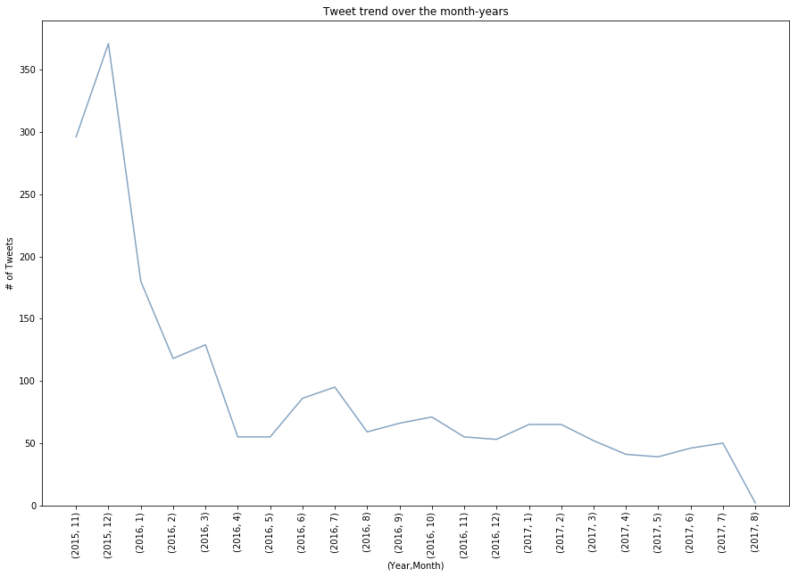

```python
#datatime is not in datetime foramt
df['timestamp'] = pd.to_datetime(df['timestamp'])
plt.figure(figsize = [15,10])

ax = df.tweet_id.groupby([df["timestamp"].dt.year, df["timestamp"].dt.month]).count()
ax.plot('line', title='Tweet trend over the month-years',color=(0.2, 0.4, 0.6, 0.6) )

ax.set_axis(new_labels,axis=0,inplace=True)

new_labels=['(2015, 11)', '(2015, 12)', '(2016, 1)', '(2016, 2)', '(2016, 3)', '(2016, 4)', '(2016, 5)', '(2016, 6)', '(2016, 7)', '(2016, 8)', '(2016, 9)', '(2016, 10)', '(2016, 11)', '(2016, 12)', '(2017, 1)', '(2017, 2)', '(2017, 3)', '(2017, 4)', '(2017, 5)', '(2017, 6)', '(2017, 7)', '(2017, 8)']

ticks_prop = np.arange(0,len(new_labels),1)

plt.xlabel("(Year,Month)")
plt.ylabel("# of Tweets")
plt.ylim(0, )
plt.xticks(ticks_prop,new_labels,rotation=90)

plt.draw()

#save result
plt.savefig('img-results/tweetTrend.png', bbox_inches='tight')
```

```python
df.tweet_id.groupby([df["timestamp"].dt.year, df["timestamp"].dt.month]).count()
```

```
timestamp  timestamp
2015       11           296
           12           371
2016       1            180
           2            118
           3            129
           4             55
           5             55
           6             86
           7             95
           8             59
           9             66
           10            71
           11            55
           12            53
2017       1             65
           2             65
           3             52
           4             41
           5             39
           6             46
           7             50
           8              2
Name: tweet_id, dtype: int64
```

It looks like "WeRateDogs" was quite popular in 2015. However, the usage has dropped to below 100 tweets per month from April 2016.

### Most common dog names

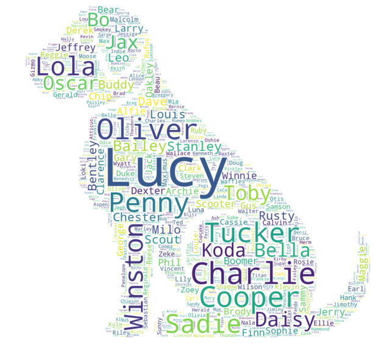

```python
#generate an array from the image
mask = np.array(Image.open('dog-outline.jpg'))

# Create a frequency dictionary of the dog names
fields = ['name']
text = pd.read_csv('twitter_archive_master.csv', usecols=fields).dropna()
text = df['name'].dropna()
text = text.value_counts()
text=text.to_dict()

#generate a word cloud with the mask image
wc = WordCloud(mask=mask,background_color="white",max_words=2000, max_font_size=256,random_state=42,width =2000,height = 2000)
wcloud = wc.generate_from_frequencies(text)

plt.figure(figsize = [15,10])
plt.imshow(wcloud, interpolation='bilinear')
plt.axis("off")

#save result
plt.savefig('img-results/nameCloud.png', bbox_inches='tight')
```

Lucy and Charlie are the most common dog name (appearing 11 times). Other popular names are Cooper(10 times) , Oliver(10 times) and Tucker(9 times).

```python
#function to describe a column
def describeColumn(fields):
    text = pd.read_csv('twitter_archive_master.csv', usecols=fields).dropna()
    text = df[fields].dropna()
    return text.describe()
```

```python
describeColumn(['name'])
```

|  | name |
| --- | --- |
| count | 1411 |
| unique | 947 |
| top | Charlie |
| freq | 11 |

### Percentage of sources used by users

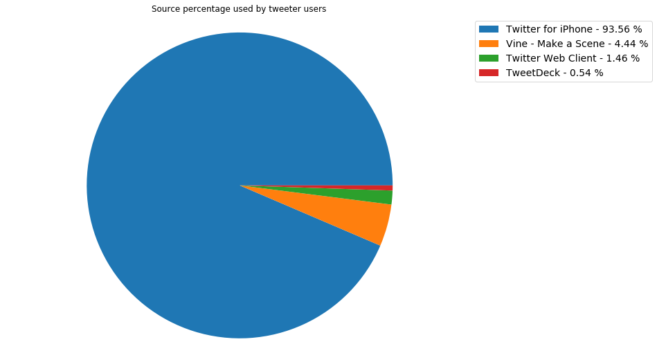

```python
my_labels = df.source.value_counts().index.tolist()
my_counts = df.source.value_counts()

x = np.char.array(df.source.value_counts().index.tolist())
y = np.array(df.source.value_counts())

#calculate percentage
porcent = 100.*y/y.sum()

#plot pie
patches, texts = plt.pie(y, startangle=0, radius=1.8)

#create labels for legend
labels = ['{0} - {1:1.2f} %'.format(i,j) for i,j in zip(x, porcent)]

sort_legend = True
if sort_legend:
    patches, labels, dummy =  zip(*sorted(zip(patches, labels, y),
                                          key=lambda x: x[2],
                                          reverse=True))
#set legend
plt.legend(patches, labels, loc='upper center', bbox_to_anchor=(1.2, 1.),
           fontsize=14)

#set title of the chart
plt.title.position = "bottom"
plt.title("Source percentage used by tweeter users")


#adjust pie chart
plt.axis('equal')
plt.rcParams["figure.figsize"] = [15, 9]
plt.savefig('img-results/tweetSources.png', bbox_inches='tight')
```

More than 93% of the tweets come from Twitter iPhone users.

### Relation between dog stages and retweets

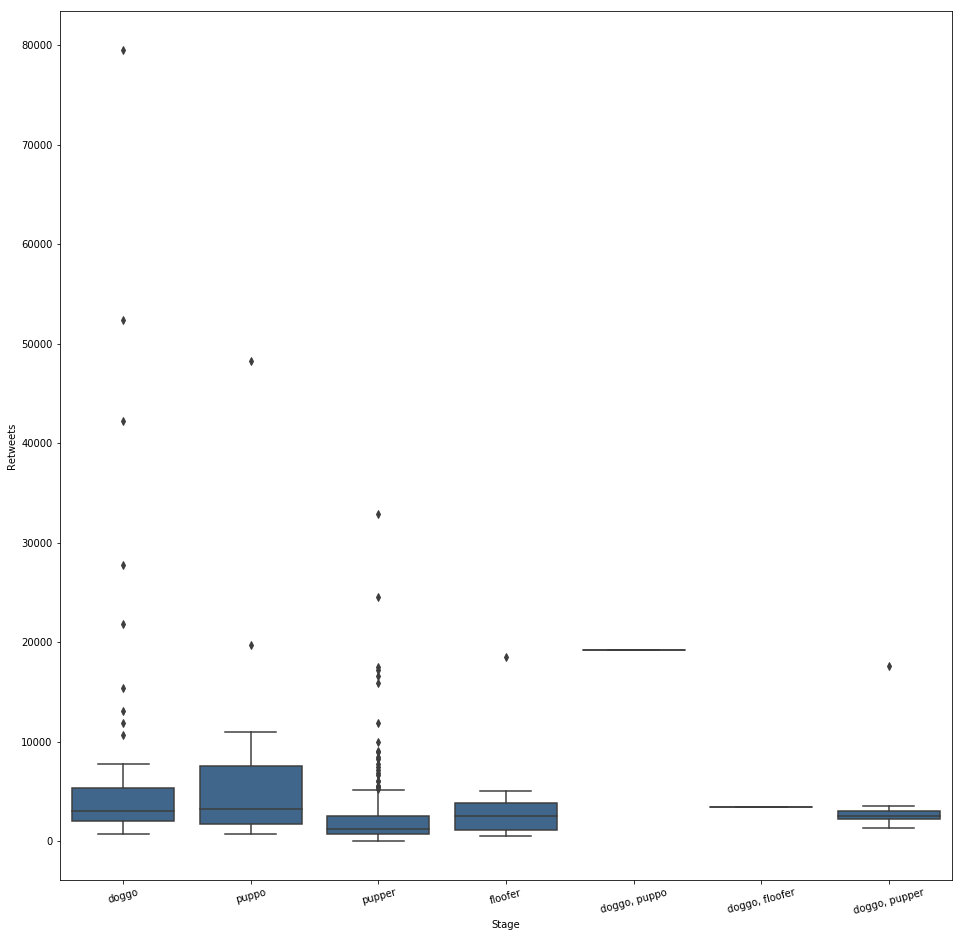

```python
df_cmp = df[['retweet_count','stage']]

plt.figure(figsize = [16,16])

sns.boxplot(data=df_cmp,x='stage',y='retweet_count',color=(0.2, 0.4, 0.6, 0.6))

plt.xlabel('Stage')

plt.ylabel('Retweets')

plt.xticks(rotation=15)

#save visualization
plt.savefig('img-results/relationship.png')
```

```python
df_cmp.groupby('stage').describe()
```

| stage | retweet_count count | retweet_count mean | retweet_count std | retweet_count min | retweet_count 25% | retweet_count 50% | retweet_count 75% | retweet_count max |
| --- | --- | --- | --- | --- | --- | --- | --- | --- |
| doggo | 72.0 | 6610.361111 | 12118.212588 | 725.0 | 2001.50 | 3011.0 | 5329.50 | 79515.0 |
| doggo, floofer | 1.0 | 3433.000000 | NaN | 3433.0 | 3433.00 | 3433.0 | 3433.00 | 3433.0 |
| doggo, pupper | 10.0 | 3971.200000 | 4843.038459 | 1265.0 | 2237.00 | 2543.0 | 3053.25 | 17621.0 |
| doggo, puppo | 1.0 | 19196.000000 | NaN | 19196.0 | 19196.00 | 19196.0 | 19196.00 | 19196.0 |
| floofer | 9.0 | 4155.888889 | 5590.254566 | 496.0 | 1141.00 | 2509.0 | 3825.00 | 18497.0 |
| pupper | 222.0 | 2470.558559 | 3777.620013 | 26.0 | 689.75 | 1246.5 | 2485.50 | 32883.0 |
| puppo | 23.0 | 6600.043478 | 10083.218234 | 716.0 | 1721.00 | 3220.0 | 7541.50 | 48265.0 |

```python
describeColumn(['stage'])
```

|  | stage |
| --- | --- |
| count | 338 |
| unique | 7 |
| top | pupper |
| freq | 222 |

### Top 10 most tweeted dog breeds

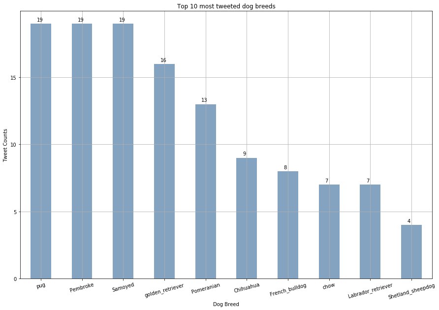

```python
ax = df.breed.value_counts().nlargest(10).plot("bar",grid = True, figsize=(15,10),title="Top 10 most tweeted dog breeds",color=(0.2, 0.4, 0.6, 0.6))
ax.set_xlabel("Dog Breed")
ax.set_ylabel("Tweet Counts")
ax.set_ylim([0,None])
ax.set_yticks(np.arange(0,20, step=5))

plt.xticks(rotation=15)

# find the values and append to list
for i in range(df.breed.value_counts().nlargest(10).shape[0]):
    count = df.breed.value_counts().nlargest(10).values[i]
    ax.text(i - 0.1, count + 0.3,str(count),va = 'center')


#save visualization
plt.savefig('img-results/dogbreeds.png')
```

```python
describeColumn(['breed'])
```

|  | breed |
| --- | --- |
| count | 181 |
| unique | 44 |
| top | Pembroke |
| freq | 19 |

### Rating distibution of dogs

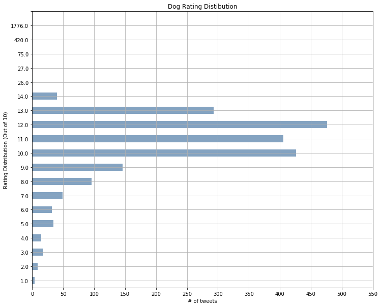

```python
rplot = df.rating_numerator.value_counts().sort_index().plot(kind='barh', grid = True, figsize=(12,10),title='Dog Rating Distibution',color=(0.2, 0.4, 0.6, 0.6))
rplot.set_xlabel("# of tweets")
rplot.set_ylabel("Rating Distribution (Out of 10)")
rplot.set_xticks(np.arange(0,600, step=50))
rplot.set_yticks(np.arange(0,20, step=1))

#save visualization
plt.savefig('img-results/rating-distribution.png')
```

```python
df['rating_numerator'].value_counts()
```

```
12.0      476
10.0      426
11.0      406
13.0      293
9.0       146
8.0        96
7.0        49
14.0       40
5.0        34
6.0        32
3.0        18
4.0        15
2.0         9
1.0         4
26.0        1
1776.0      1
27.0        1
420.0       1
75.0        1
Name: rating_numerator, dtype: int64
```

Most of the tweets have rated their dogs from 10 to 13. We see a lot of outliers after rating 14

### All time top favorite dog image

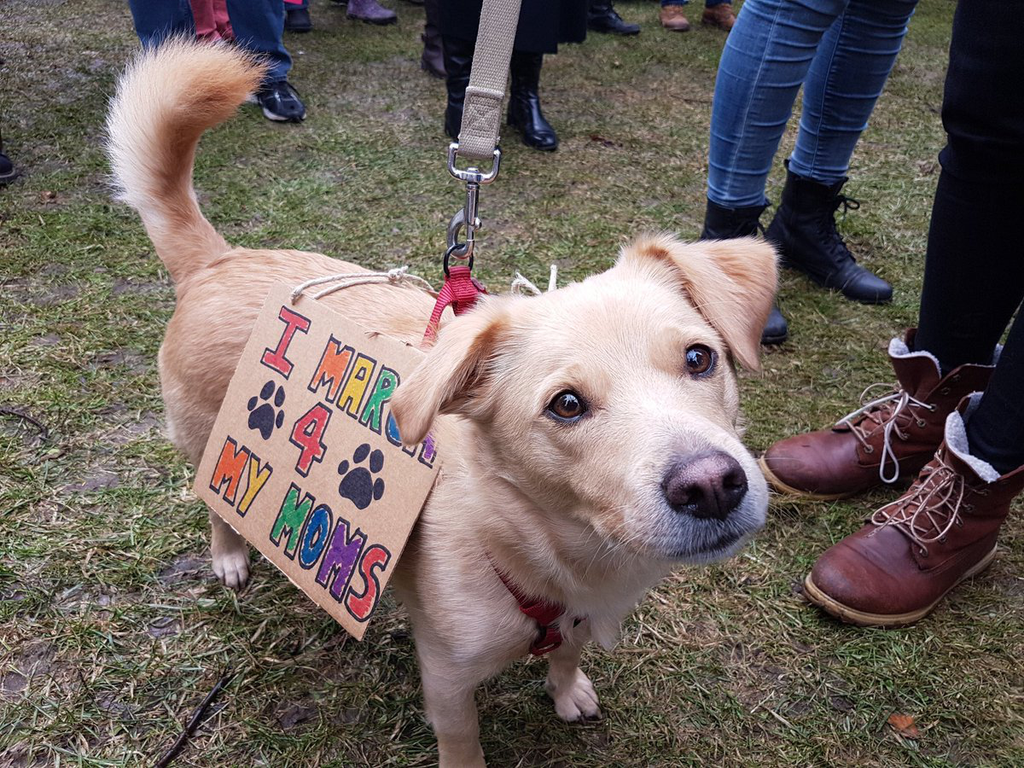

```python
#get url of the dog with highest favorite count
image_url=df.loc[df['favorite_count'].idxmax(), 'jpg_url']
response = req.get(image_url)
img = Image.open(BytesIO(response.content))
image_url
#save visualization
urllib.request.urlretrieve(image_url, "img-results/fav-dog.jpg")

img
```